# How to visualise data in R

# 3 Some more advanced recipes

Add a histogram to a scatterplot using `ggExtra::ggMarginal`. This requires you to set up the basic plot first and save as an object.

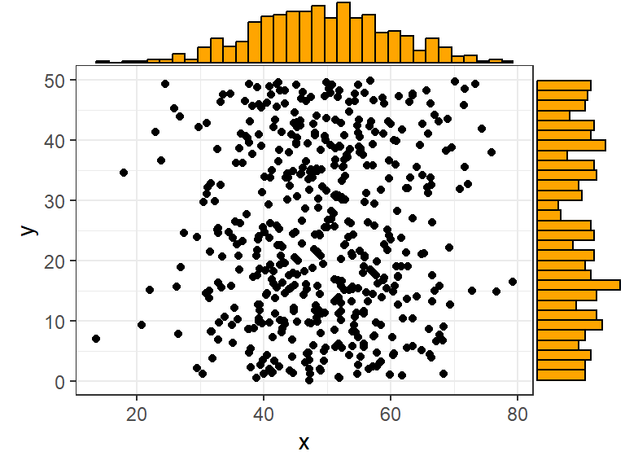

```r
# create data
set.seed(30)
df1 = data.frame(x = rnorm(500, 50, 10), y = runif(500, 0, 50))
# set up base plot
p1 = ggplot(df1, aes(x, y)) + geom_point() + theme_bw()

ggMarginal(p1, type = "histogram",
           margins = "both", # note: "x", "y", or "both"
           fill = "orange",
           xparams = list(binwidth = 2))
```

```r
# if you have lots of comparisons:
vars = c("att8", "ks2emss", "ks4_pupils")

plots = lapply(vars, function(v) {

  p = ggplot(
    model_data,
    aes(x = .data[[v]], y = study_leave_rate_5ht)) +
    geom_point(alpha = 0.3)

  ggExtra::ggMarginal(
    p,
    type = "histogram",
    fill = "orange"
  )
})

patchwork::wrap_plots(plots, nrow=1, ncol=3)
```

Create a scatterplot matrix using `GGally::ggpairs`. This is quite customisable depending on what you need. Check `help(ggpairs)`

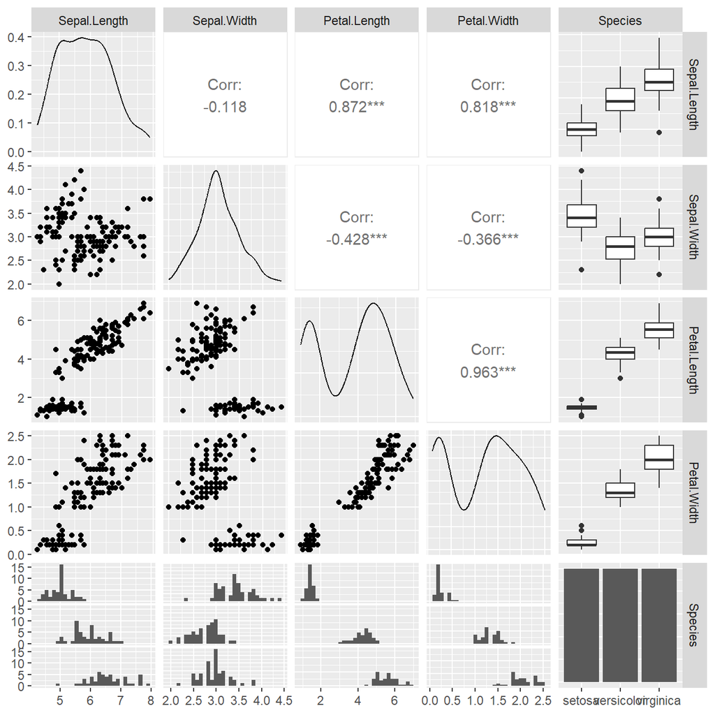

```r
# note: you can also add colouring by factor if you add: ggplot2::aes(colour = Species)
GGally::ggpairs(iris)
```

# 4 Plotting statistical summary data

Often we want to plot statistical summaries rather than raw data. `ggplot` has functions to do this “in-plot”, i.e. instead of you having to compute summaries manually beforehand. One option is to use arguments within `geom_bar`.

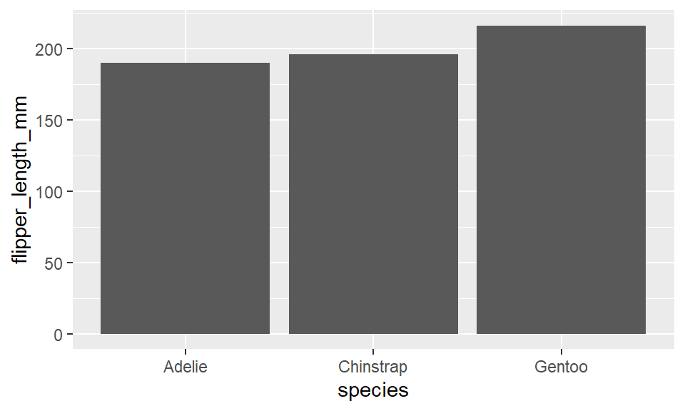

```r
palmerpenguins::penguins %>%
  ggplot(aes(x = species, y = flipper_length_mm)) +
  geom_bar(fun = "median",
           stat = "summary")
```

However, a more powerful method is to use `stat_summary`. You can plot several summaries together, e.g. if you want points and lines on the same plot.

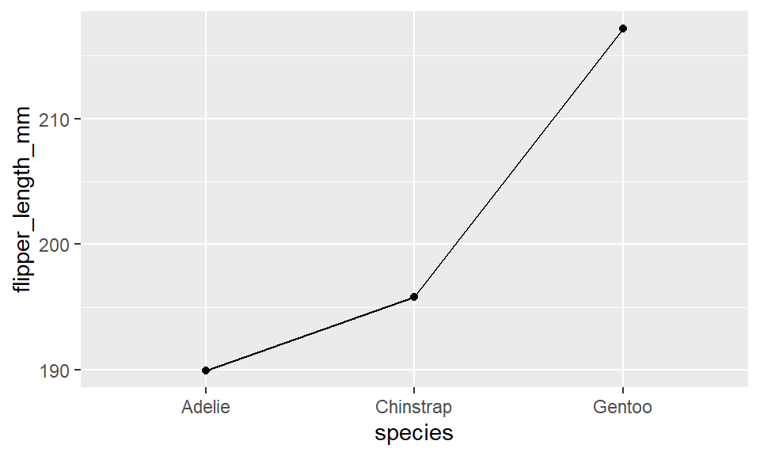

```r
palmerpenguins::penguins %>%
  ggplot(aes(x = species, y = flipper_length_mm)) +
  stat_summary(fun = "mean", geom = "point") +
  stat_summary(fun = "mean", geom = "line", aes(group = 1))
```

Plot the mean and standard deviation using `mean_sdl` (use the `mult` argument to change how many standard deviations are shown around the mean):

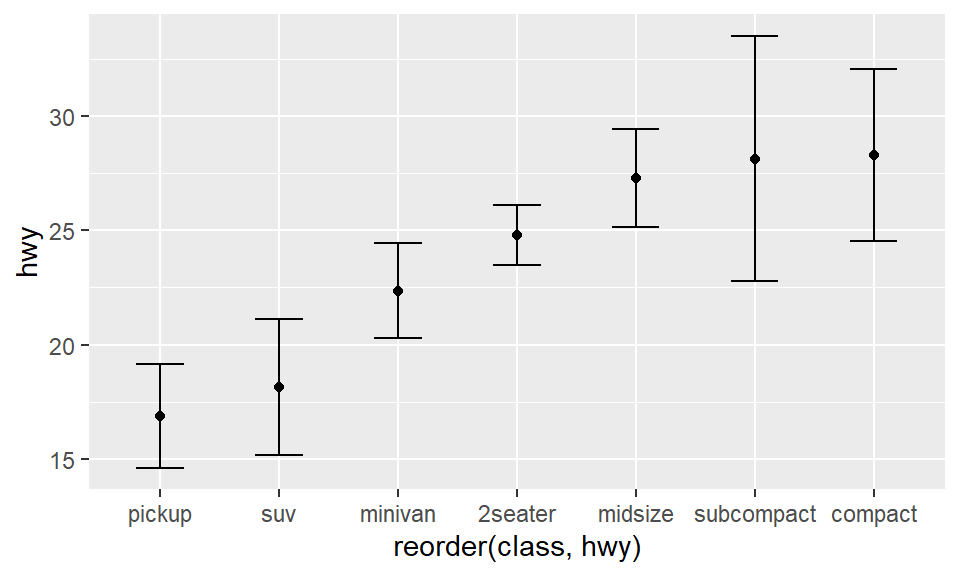

```r
mpg %>%
  ggplot(aes(x = reorder(class, hwy), y = hwy)) +
  stat_summary(fun = mean, geom = "point") +
  stat_summary(fun.data = mean_sdl,
               fun.args = list(mult = 1),
               geom = "errorbar",
               width = .4)
```

NOTE that `geom_linerange` doesn’t have horizontal hatches at the tops of the bars - for this you need to use `geom_errorbar`, which has a `width` argument to control the length of them.

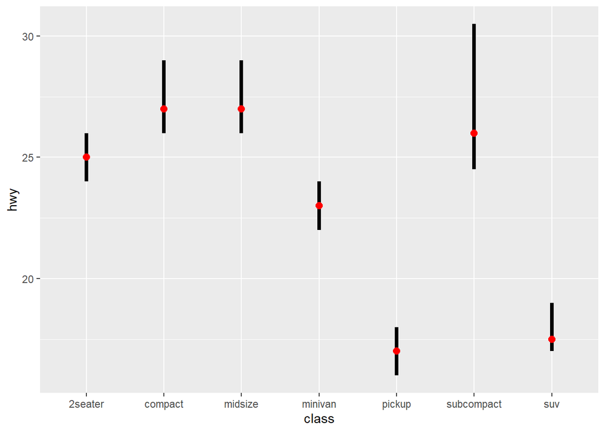

```r
# custom function
median_IQR <- function(x) {
  data.frame(y = median(x), # Median
             ymin = quantile(x)[2], # 1st quartile
             ymax = quantile(x)[4])  # 3rd quartile
}

mpg %>%
  ggplot(aes(x = class, y = hwy)) +
  stat_summary(geom = "linerange",
               fun.data = median_IQR,
               linewidth = 1.5) +
  stat_summary(fun = median, geom = "point", colour = "red", size = 2.5)
```

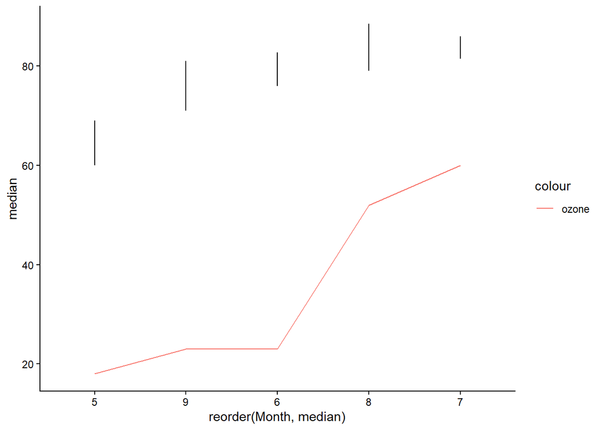

```r
# Another option if you want to plot manually created min and max values, and add
# a separate variable as well as the linerange:
# NOTE: you must wrap quantile() in as.numeric() otherwise this will produce a
# NAMED vector instead of scalar values which can cause issues when rending Quarto.
data = airquality %>%
  group_by(Month) %>%
  summarise(q1 = as.numeric(quantile(Temp, na.rm=T, probs=0.25)),
            median = median(Temp, na.rm=T),
            q3 = as.numeric(quantile(Temp, na.rm=T, probs=0.75)),
            ozone = median(Ozone, na.rm=T))

data %>%
  ggplot(aes(x = reorder(Month, median), y = median)) +
  geom_linerange(aes(ymin = q1, ymax = q3)) +
  geom_line(aes(y = ozone, colour = "ozone", group = 1)) +
  theme_classic()
```

You could also use `geom_ribbon` instead (this time there’s a grouping factor and the median is superimposed in the ribbons too):

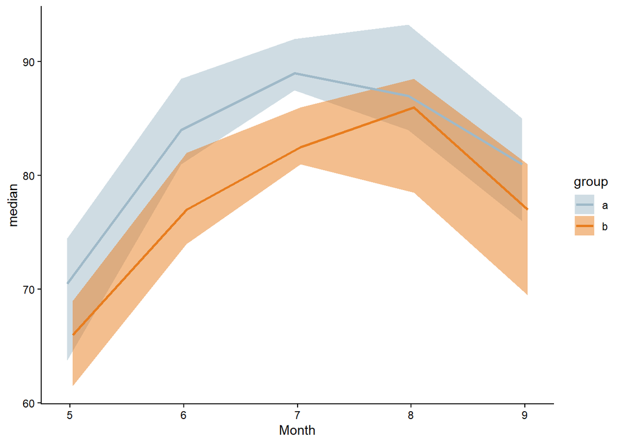

```r
data2 = airquality %>%
  mutate(group = rep(c("a", "b"), length.out = n())) %>%
  group_by(Month, group) %>%
  summarise(q1 = as.numeric(quantile(Temp, na.rm=T, probs=0.25)),
            median = median(Temp, na.rm=T),
            q3 = as.numeric(quantile(Temp, na.rm=T, probs=0.75)),
            ozone = median(Ozone, na.rm=T)) %>%
  mutate(q1 = if_else(group == "a", q1+5, q1),
         q3 = if_else(group == "a", q3+5, q3),
         median = if_else(group == "a", median+5, median))

data2 %>%
  ggplot(aes(x = Month)) +
  geom_ribbon(data = data2, aes(ymin = q1, ymax = q3, group = group, fill = group),
                 position = position_dodge(width = 0.1), alpha = 0.5) +
  geom_line(aes(y = median, colour = group, group = group),
            position = position_dodge(width = 0.1), linewidth = 1) +
  theme_classic() +
  scale_fill_manual(values = c("#9FB9C8", "#E87D1E"),
                        breaks = c("a", "b"),
                        labels = c("a", "b")) +
  scale_colour_manual(values = c("#9FB9C8", "#E87D1E"),
                        breaks = c("a", "b"),
                        labels = c("a", "b"))
```

Add confidence intervals (requires the `Hmisc` package):

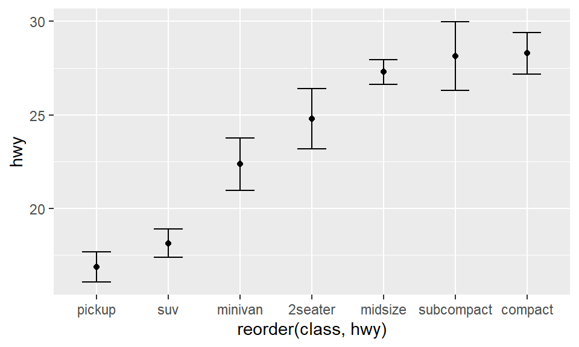

```r
mpg %>%
  ggplot(aes(x = reorder(class, hwy), y = hwy)) +
  stat_summary(fun = "mean", geom = "point") +
  stat_summary(fun.data = "mean_cl_normal",
               fun.args = list(conf.int = .95),
               geom = "errorbar",
               width = .4)
```

## 4.1 Pointrange

This shows the mean and SE.

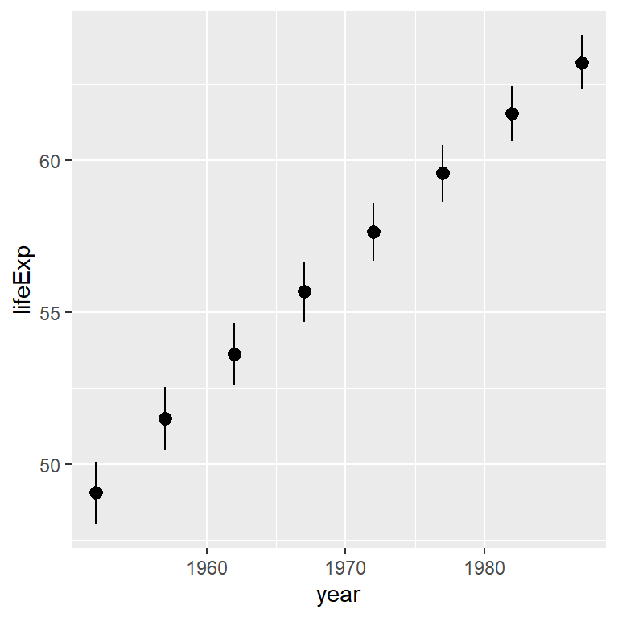

```r
gapminder::gapminder %>%
  filter(year %in% c(1950:1990)) %>%
  ggplot() +
  geom_pointrange(mapping = aes(x = year, y = lifeExp),
                  stat = "summary")
```

# 5 Working with text

This diagram shows the main text elements in a ggplot2 graph, all of which are controllable (see below).

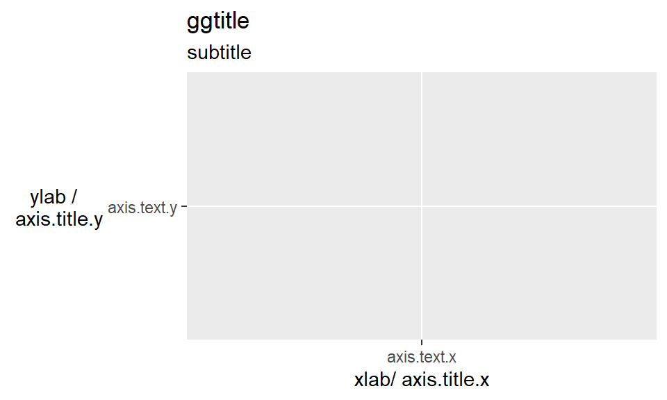

## 5.1 Plot title, subtitle, and caption

```r
p + ggtitle("Main plot title", subtitle = "Plot subtitle")

# use labs to add a caption/footnote at the bottom right of the plot
p + labs(caption = "my caption")

# caption is right-justified by default. To change:
p + theme(plot.caption = element_text(hjust=0))

# centre align plot title
p + theme(plot.title = element_text(hjust = 0.5))

# change plot title size
p + theme(plot.title = element_text(size = 18))
```

## 5.2 Adding text to charts

If you just want to add static text somewhere on a chart, use this:

```r
# for plot with numeric axes:
plot + geom_text(x = 100, y = 100, label = "my label", hjust = 1.2)
```

```r
# for plot with date on x-axis
plot + geom_text(x = as.Date("2025-09-01"), y = 100, label = "my label", hjust = 1.2)
```

To add text from the underlying dataframe, you can use either `geom_text` or `geom_label`. The latter will give you padding around the figures.

### 5.2.1 `geom_label`

The example below calculates percentage changes for each month for 3 variables and adds text to show these percentages. Pay attention to the legend - by default it includes little ‘a’ characters because it’s linked to text. To turn this off, specify `show_legend = F` in `geom_label` (then the legend will revert to showing dots and lines).

Note that if you don’t want any padding or filling of the box around the text, make sure to specify `fill = NA, border_colour = NA` in geom_label.

```r
df = airquality %>%
  group_by(Month) %>%
  summarise(ozone_m = mean(Ozone, na.rm=T),
            solar_m = mean(Solar.R, na.rm=T),
            wind_m = mean(Wind, na.rm=T)) %>%
  pivot_longer(-c(Month)) %>%
  arrange(name, Month) %>%
  group_by(name) %>%
  mutate(lag = dplyr::lag(value, n = 1, default = NA)) %>%
  mutate(diff = value - lag) %>%
  mutate(change_pc = diff / lag * 100)
df
```

| Month | name | value | lag | diff | change_pc |
| --- | --- | --- | --- | --- | --- |
| 5 | ozone_m | 23.615385 | NA | NA | NA |
| 6 | ozone_m | 29.444444 | 23.615385 | 5.8290598 | 24.683315 |
| 7 | ozone_m | 59.115385 | 29.444444 | 29.6709402 | 100.769231 |
| 8 | ozone_m | 59.961539 | 59.115385 | 0.8461538 | 1.431360 |
| 9 | ozone_m | 31.448276 | 59.961539 | -28.5132626 | -47.552587 |
| 5 | solar_m | 181.296296 | NA | NA | NA |
| 6 | solar_m | 190.166667 | 181.296296 | 8.8703704 | 4.892748 |
| 7 | solar_m | 216.483871 | 190.166667 | 26.3172043 | 13.839021 |
| 8 | solar_m | 171.857143 | 216.483871 | -44.6267281 | -20.614343 |
| 9 | solar_m | 167.433333 | 171.857143 | -4.4238095 | -2.574120 |
| 5 | wind_m | 11.622581 | NA | NA | NA |
| 6 | wind_m | 10.266667 | 11.622581 | -1.3559140 | -11.666204 |
| 7 | wind_m | 8.941935 | 10.266667 | -1.3247312 | -12.903226 |
| 8 | wind_m | 8.793548 | 8.941935 | -0.1483871 | -1.659452 |
| 9 | wind_m | 10.180000 | 8.793548 | 1.3864516 | 15.766691 |

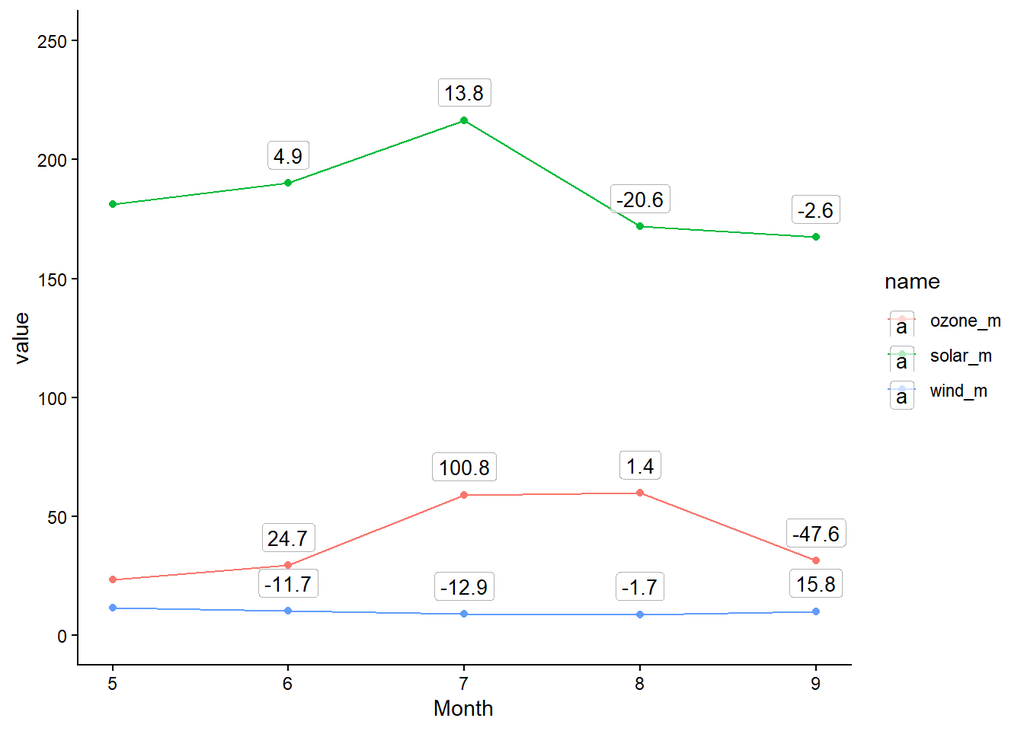

```r
df %>%
  ggplot(aes(x = Month, y = value, group = name, colour = name)) +
  geom_line() +
  geom_point() +
  geom_label(aes(label = round(change_pc,1)),
             size = 3.5,
             alpha = 0.7,
             vjust = -0.5,
             colour = "black", # if you don't want text to be coloured
             border.colour = "grey70",
             show.legend = T) +
  theme_classic() +
  coord_cartesian(ylim = c(0,250))
```

### 5.2.2 `geom_text`

Recipe to add figures to the top of a bar.

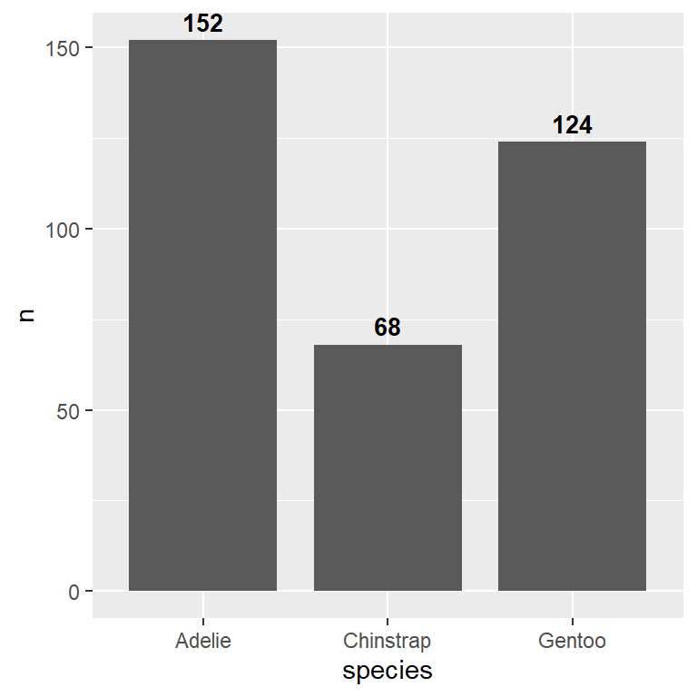

```r
palmerpenguins::penguins %>%
  group_by(species) %>%
  summarise(n = n()) %>%
  ggplot(aes(x = species, y = n)) +
  geom_bar(stat = "identity", width = 0.8) +
  geom_text(
    aes(label = n, vjust = -0.5),
    size = 3.5,
    fontface = "bold")
```

```r
# if you have stacked bars, place the figures in the middle of each bar by
# adding this to geom_text:
# position = position_stack(vjust = .5)
```

It’s also possible to display text for certain conditions.

```r
# p + geom_text(aes(label = ifelse(condition == "con", paste0(round(diff_pc,1), "%"), ""), vjust = -0.5),size = 3.5)

# a more common strategy is to calculate bar counts beforehand and then plug these in later.
bar_data = ela_final %>%
  filter(!is.na(status)) %>%
  # reorder the factor so that the order of filled bars is descending (first
  # on top, last at bottom)
  mutate(status = factor(status, levels = c("Deceased", "Cancelled", "Rejected",
                                            "Waiting list", "Matching",
                                            "Applicant withdrawn", "Allocated"))) %>%
  count(AY, status)

ggplot(bar_data, aes(x = AY, y = n, fill = status)) +
  geom_bar(stat = "identity") +
  geom_text(
    # just show counts from "Allocated" status
    data = bar_data %>% filter(status == "Allocated"),
    aes(x = AY, y = n, label = n),
    position = position_stack(vjust = 0.5),
    color = "black",
    size = 3.5
  )
```

# 6 Axes

Note that the same functions are used for x or y axes - adjust accordingly.

```r
# custom axis titles
p + xlab("...")
p + ylab("...")

# remove axis title
p + theme(axis.title.x = element_blank())

# change axis title text size
p + theme(axis.title.x = element_text(size = 14))

# rotate x- axis title text 45 degrees
p + theme(axis.title.x = element_text(angle = 45, vjust = 0.5))

# rotate y-axis to 0 degrees (to be read horizontally not vertically)
p + theme(axis.title.y = element_text(angle = 0, vjust = 0.5))

# remove tick marks
p + theme(axis.ticks.x = element_blank())
```

## 6.1 Axis formatting options

```r
# percent labels with breaks of 10-100%
# note: change scale to 0 if you are working with integers already, otherwise leave at default of 100
p + scale_y_continuous(labels = scales::label_percent(accuracy = 1, scale = 100), breaks = (0:10)/10)

# currency suffix
p + scale_y_continuous(labels = scales::label_dollar(prefix = "£"),
                       breaks = seq(0, 100, by = 25))
# can also specify suffix, big.mark = ",", and decimal.mark = "."

# if you just want to display all breaks without listing them:
p + scale_x_continuous(n.breaks = 17)

# thousands separator
p + scale_y_continuous(labels = scales::label_comma(big.mark = ","))

# dates and times
p + scale_y_continuous(labels = label_date(format = "%Y-%m-%d"))
p + scale_y_continuous(labels = label_time(format = "%H:%M:%S"))
```

Using `scale_x_date`: this requires the x-axis to be formatted as a date object.

```r
# firstly, a nifty function if your date value is in the format "201516"
convert_year = function(year){
  yr = substr(year, 5, 6)
  full_yr = paste0("20", yr, "-01-01")
  full_yr_date = as.Date(full_yr, format = "%Y-%m-%d")
}

# Note that you can either supply date_labels OR a character vector of custom labels, not both.
p + scale_x_date(date_labels = "%Y", date_breaks = "1 year")

# if your x-axis is in date format, you can try the following:
yrs = c(as.Date("2016-06-01"), as.Date("2017-06-01"), as.Date("2018-06-01"))
yrs_labs = c("15/16", "16/17", "17/18")
p + scale_x_date(breaks = yrs,
                 labels = yrs_labs)

# I've found that I get an error saying `breaks` and `labels` have different lengths, so I just supply a dummy value first and this seems to fix it (the dummy value itself isn't displayed).
p + scale_x_date(labels = c("x", "12/13", "13/14", "14/15", "15/16", "16/17", "17/18", "18/19"))

# to show specific dates only
p + scale_x_date(breaks = as.Date(c("2022-07-01", "2022-07-03", "2022-07-05")))

# sometimes it's difficult to see why axis breaks don't match up with labels. In this case it can be
# useful to save the graph as an object and then inspect its breaks:
layer_scales(graph_object)$x$break_positions()
```

## 6.2 Limits and ranges of axes

It’s often desirable to alter the range of axes on a graph, e.g. to start an axis at zero. Different options result in different effects - specifically, `limits` will actually cut off data points, whereas other options like `coord_cartesian` will leave the underlying data alone but just display the part of the axis you’ve specified.

```r
# coord_cartesian(xlim = c(1,1), ylim = c(1,1)) # (doesn't clip data)
# scale_x_continuous(limits = c(0, 100))
```

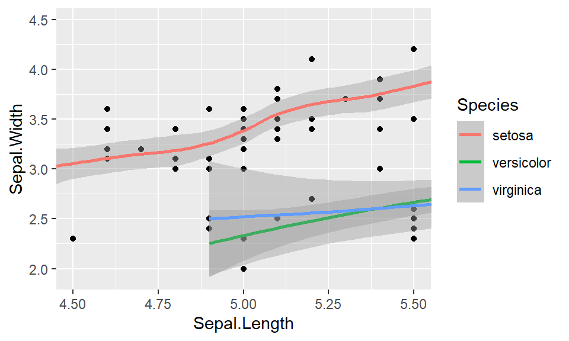

```r
iris %>%
  ggplot(aes(x = Sepal.Length, y = Sepal.Width)) + geom_point() +
  geom_smooth(aes(colour = Species)) +
  coord_cartesian(xlim = c(4.5, 5.5))
```

`coord_fixed` specifies a ratio for the display of the two axes. A 1-to-1 ratio would be a value of 1. A value <1 compresses the y-axis.

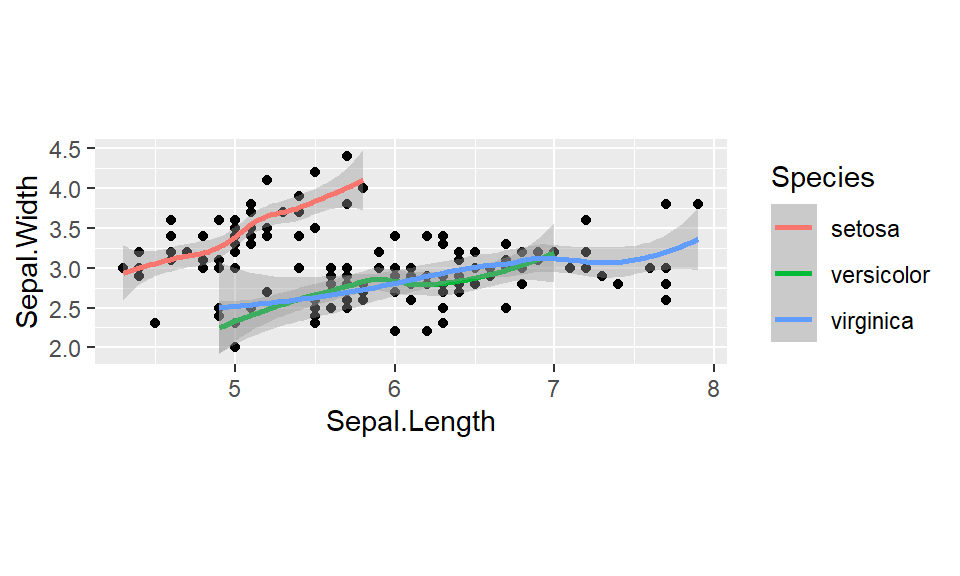

```r
# Also try e.g. coord_fixed(20/1), i.e. a 20-to-1 ratio where the x-axis is 20 times
# as long as the y-axis

iris %>%
  ggplot(aes(x = Sepal.Length, y = Sepal.Width)) + geom_point() +
  geom_smooth(aes(colour = Species)) +
  coord_fixed(0.5)
```

A tip: sometimes `coord_cartesian` doesn’t work (e.g. if you’re also using `coord_flip`), so in that case you can use the `limits` function of `scale_*_continuous` to specify the range of an axis

```r
p + scale_x_continuous(breaks = seq(0,8,by=1),
                       limits = c(0,8))
```

When you have a discrete x-axis, sometimes you get a lot of space between aesthetics and the edges of the plot. To control the spacing, add `scale_*_discrete(expand = c(0.1, 0.1))`:

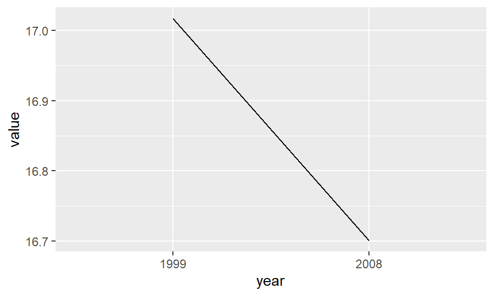

```r
# regular plot with too much padding:
padding = mpg %>%
    mutate(year = as.factor(year)) %>%
    group_by(year) %>%
    summarise(cty_m = mean(cty, na.rm = T)) %>%
    pivot_longer(c(cty_m)) %>%
    ggplot(aes(x = year, y = value)) +
    stat_summary(fun = "mean", geom = "line", aes(group = 1))

padding
```

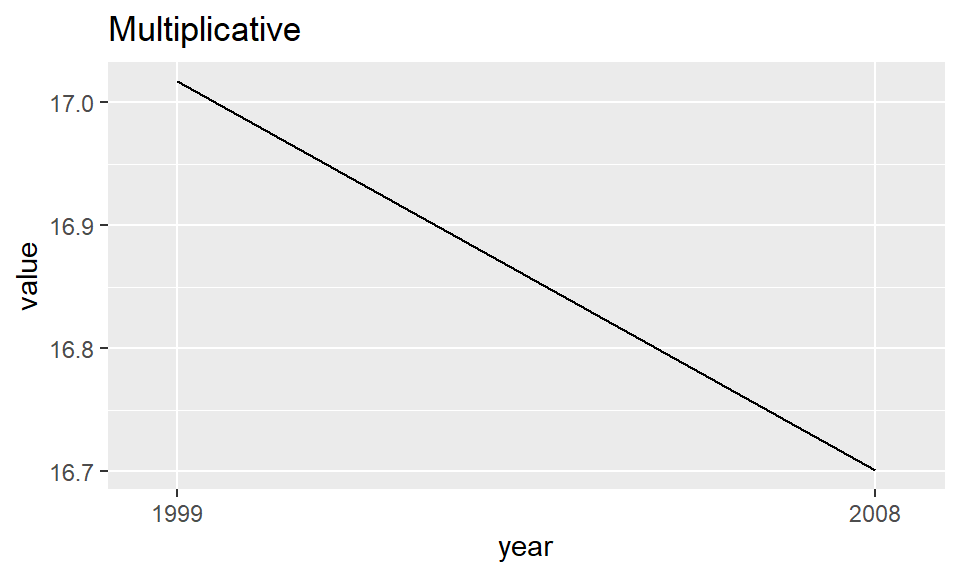

```r
# changing padding with expand:
# note that the first figure is a multiplier - what percent to expand the padding on either side;
# the second figure is an additive expansion
# also note that both of these apply symetrically to each side of the axis
padding + scale_x_discrete(expand = c(0.1, 0)) + ggtitle("Multiplicative")
```

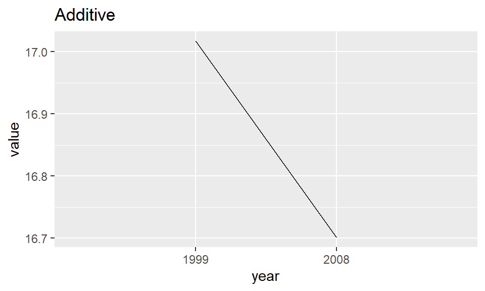

```r
padding + scale_x_discrete(expand = c(0, 1)) + ggtitle("Additive")
```

Clipping determines whether to display elements that would lie outside the plot panel. Expanding sets a buffer margin around a plot to prevent overlapping.

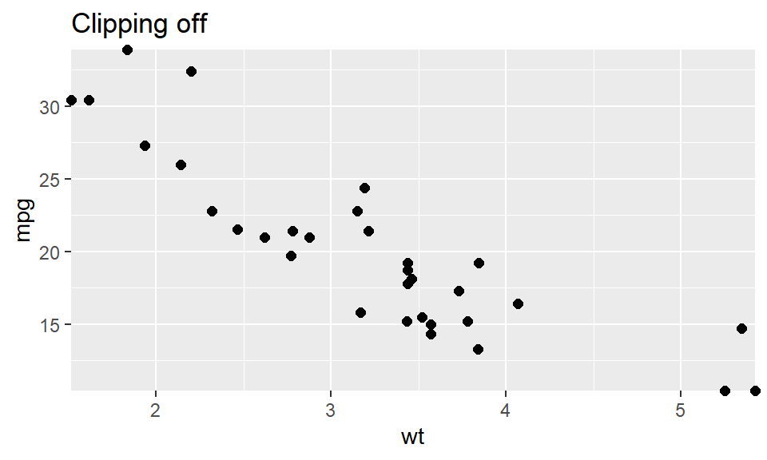

```r
ggplot(mtcars, aes(wt, mpg)) +
  geom_point(size = 2) +
  # zero expansion
  coord_cartesian(expand = F,
                  clip = "off") +
  ggtitle("Clipping off")
```

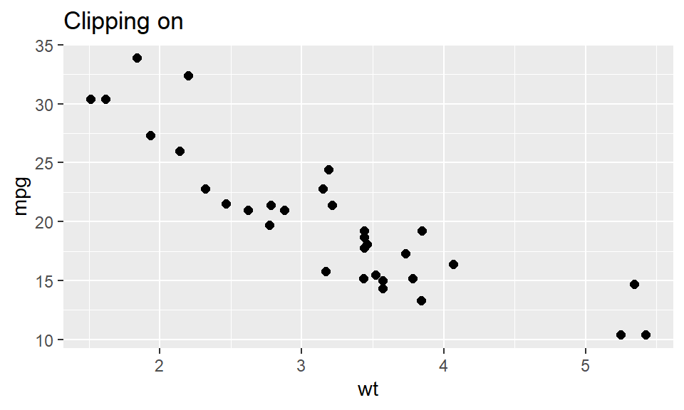

```r
ggplot(mtcars, aes(wt, mpg)) +
  geom_point(size = 2) +
  # zero expansion
  coord_cartesian(expand = T,
                  clip = "on") +
  ggtitle("Clipping on")
```

Use custom labels for x-axis: say you have numeric year labels in the data such as `202122` but you want to display these as “2021/22”.

```r
# define a list of values
yr_labels = c("2018/19", "2019/20", "2020/21", "2021/22", "2022/23")

plot + scale_x_continuous(labels = yr_labels)
```

Another option is to use an anonymous function to extract the last two digits of the year

```r
plot + scale_x_continuous(breaks = 2013:2024, labels = function(x) substr(as.character(x), 3, 4))
```

If you have a character (discrete) x-axis and want to dodge the labels, try `guide_axis`. Note that this only works if the labels are very short.

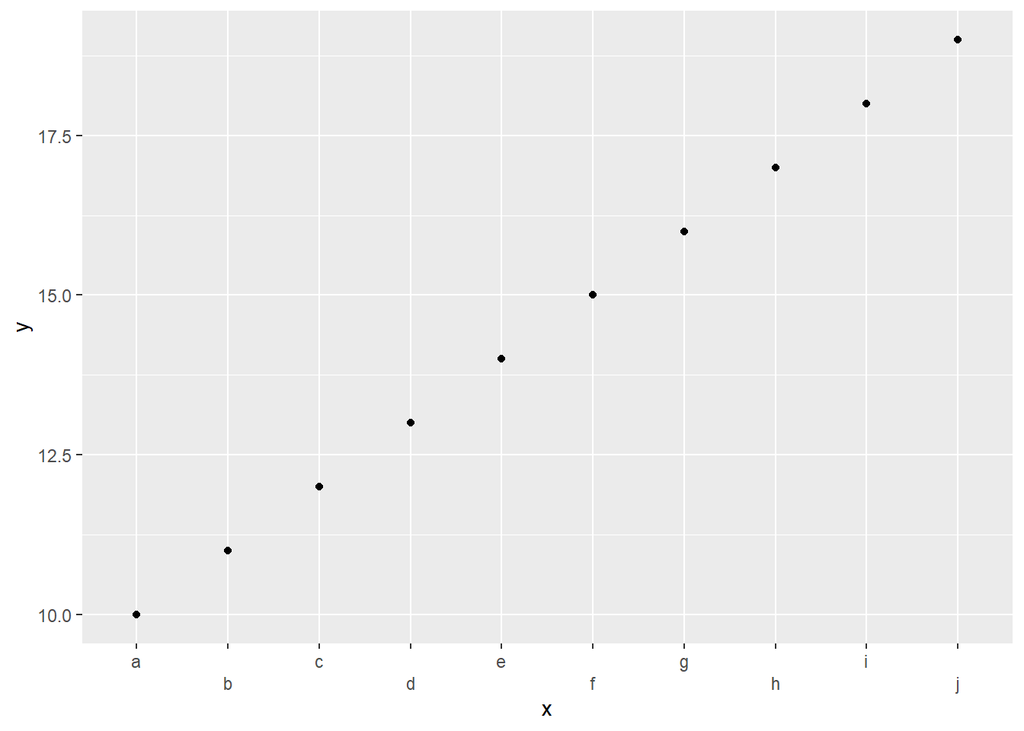

```r
df = data.frame(
  x = c("a", "b", "c", "d", "e", "f", "g", "h", "i", "j"),
  y = c(10, 11, 12, 13, 14, 15, 16, 17, 18, 19)
)

df %>%
  ggplot(aes(x = x, y = y)) +
  geom_point() +
  scale_x_discrete(guide = guide_axis(n.dodge = 2))
```

# 7 Themes

To add a pre-defined theme to a plot: `p + theme_*()`.

Tips:

- Place the `theme` argument early on in the plot sequence if you want to adjust other features e.g. axis attributes, because otherwise `theme` will override these.
- Set a global theme: `theme_set(theme_classic(base_size = 16))`.

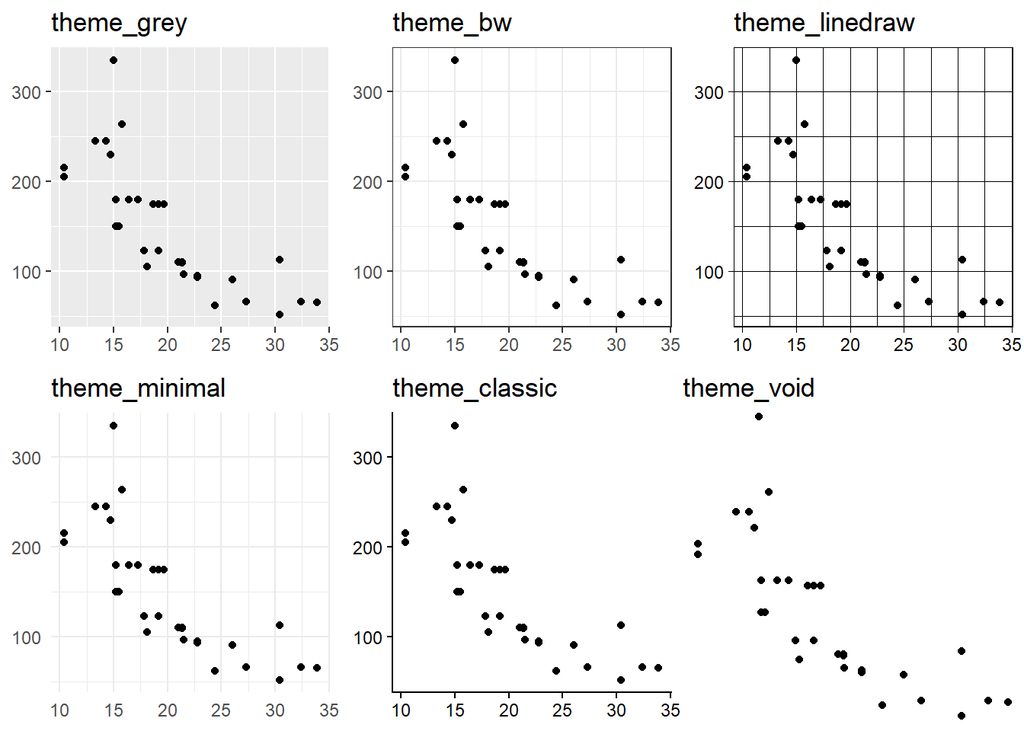

## 7.1 Analysis function theme (`afcharts`)

The AF has created its own package for producing accessible plots, based on ggplot2. The main function is `theme_af()`. It has the following arguments:

```r
theme_af(
  base_size = 14,
  base_line_size = base_size/24,
  base_rect_size = base_size/24,
  grid = c("y", "x", "xy", "none"),
  axis = c("x", "y", "xy", "none"),
  ticks = c("xy", "x", "y", "none"),
  legend = c("right", "left", "top", "bottom", "none")
)
```

See this guidance: “There’s general guidelines for research report figures here https://www.gov.uk/government/publications/research-reports-guide-and-template but there’s also a package {afcharts} that formats ggplots in line with government guidelines (https://best-practice-and-impact.github.io/afcharts/). It’s also recommended to save plots as .svg files as they’re editable outside of R”.

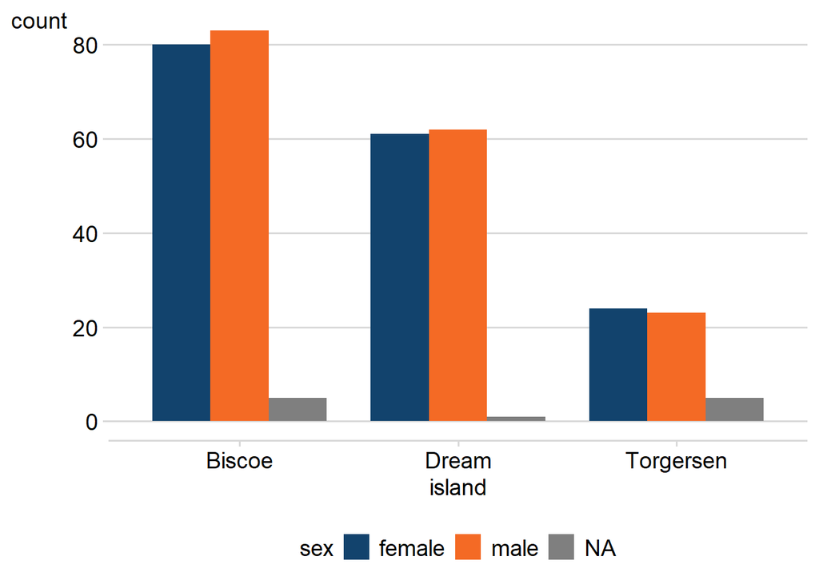

```r
afcharts::use_afcharts()

palmerpenguins::penguins %>%
  ggplot(aes(x = island, fill = sex)) +
  geom_bar(position = position_dodge(),
           width = 0.8) +
theme_af(legend = "bottom")
```

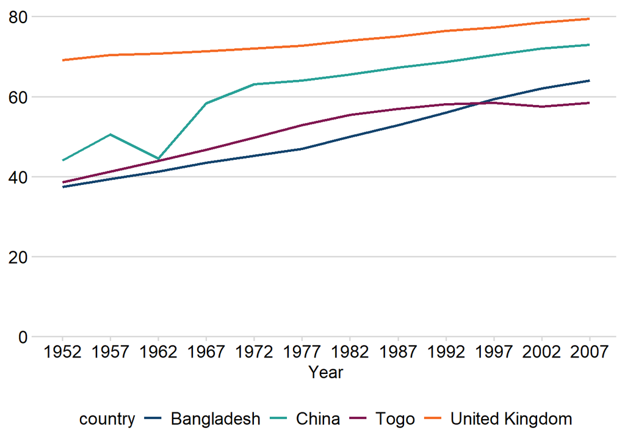

```r
gapminder %>%
  filter(country %in% c("United Kingdom", "China", "Togo", "Bangladesh")) %>%
  ggplot(aes(x = year, y = lifeExp, colour = country)) +
  geom_line(linewidth = 1) +
  theme_af(legend = "bottom") +
  scale_colour_discrete_af() +
  scale_y_continuous(limits = c(0, 82),
                     breaks = seq(0, 80, 20),
                     expand = c(0, 0)) +
  scale_x_continuous(breaks = seq(1952, 2007, 5)) +
   labs(
    x = "Year",
    y = NULL)
```

You will need to reset the default ggplot2 theme if you don’t want to use `afcharts` any more.

```r
ggplot2::theme_set(theme_grey())
```

## 7.2 A custom theme I like

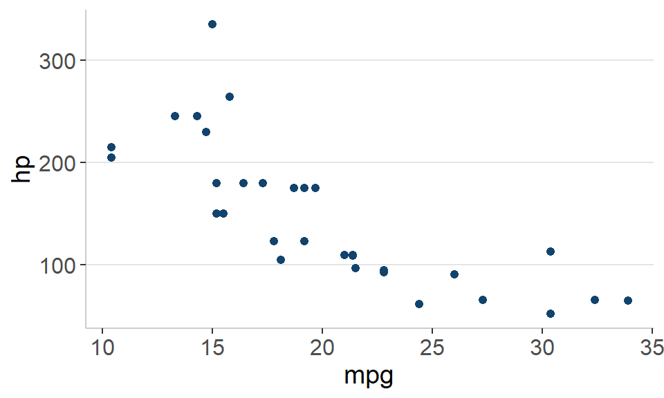

```r
# make this into a custom function that can be applied to any plot
theme_chris = function(){
  theme(
    axis.line = element_line(colour = "grey80"),
    panel.grid.major.y = element_line(colour = "grey90"),
    panel.grid.major.x = element_blank(),
    panel.background = element_rect(fill = "white", colour = NA),
    axis.title = element_text(size=14),
    axis.text = element_text(size=12),
    strip.text = element_text(size=12),#for facet_wrap panel titles
    plot.title = element_text(size=14, hjust = 0.5))
}

p + theme_chris()
```

# 8 Legends

`ggplot` will create a legend automatically if any aesthetic is mapped to a linetype, fill, or colour.

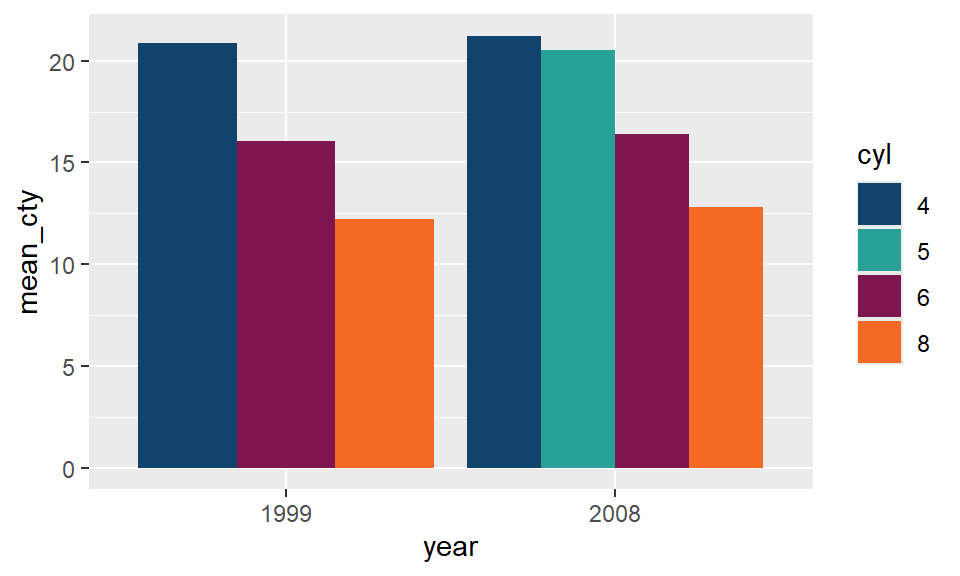

```r
# by default, legends appear on the right
p = mpg %>%
  mutate(year = as.factor(year),
         cyl = as.factor(cyl)) %>%
  group_by(year, cyl) %>%
  summarise(mean_cty = mean(cty)) %>%
  ggplot(aes(x = year, y= mean_cty, fill = cyl)) +
  scale_x_discrete(breaks = c(1999, 2008)) +
  geom_bar(stat = "identity", position = position_dodge())

p
```

```r
# To change:

p + theme(legend.position = "none")
p + theme(legend.position = "top")
p + theme(legend.position = "bottom")

# custom location for legend (first number is left-right, second is bottom-top)
p + theme(legend.position = c(0.5, 0.9))
```

To control legend wrapping (i.e. a single horizontal row instead of wrapping into two rows) - especially when `legend.position = "bottom"`.

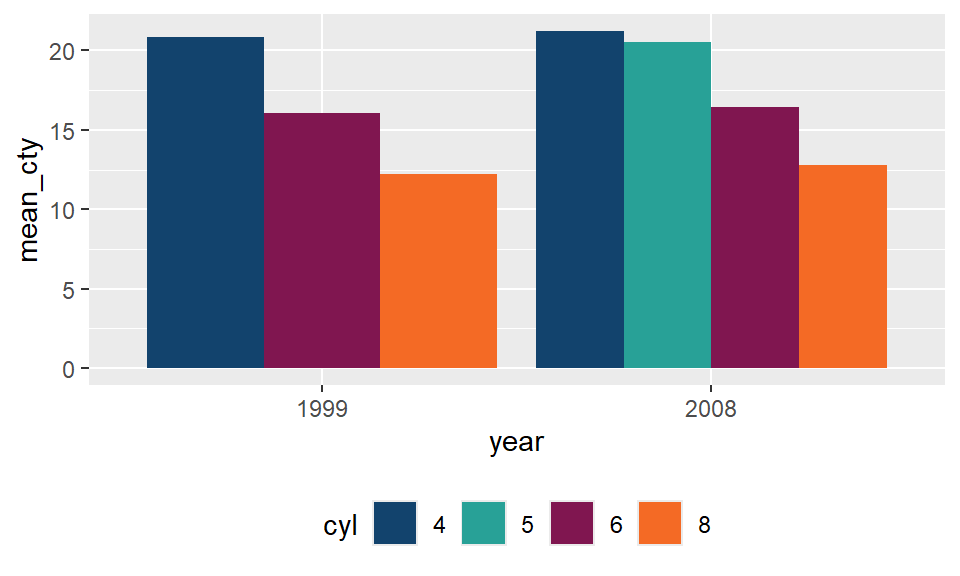

```r
p + theme(legend.position = "bottom") + guides(fill = guide_legend(nrow = 1))
```

Filling and outlining:

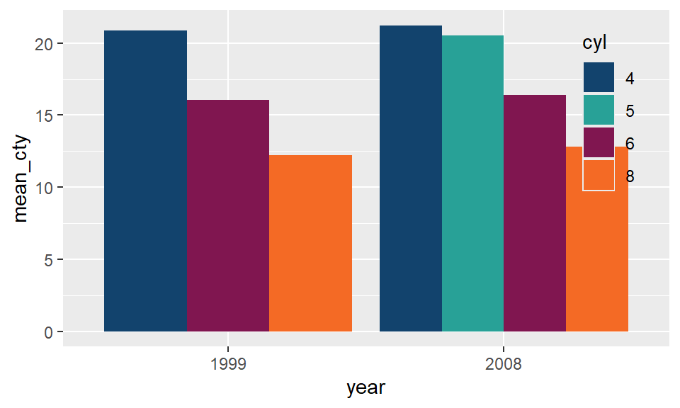

```r
# make box transparent
p + theme(legend.background = element_blank(),
          legend.position = c(0.9, 0.7))
```

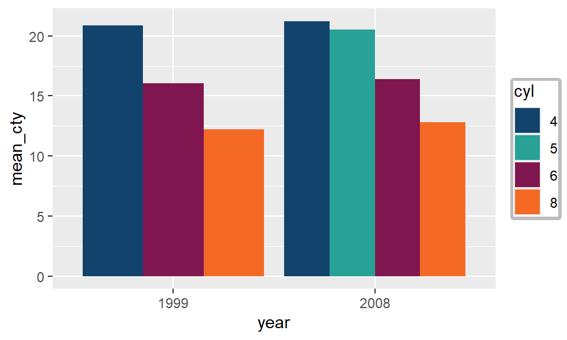

```r
# add grey box and reduce padding to zero
p + theme(legend.box.background = element_rect(colour = "grey", linewidth = 2),
          legend.margin = margin(0.5,0.5,0.5,0.5))
```

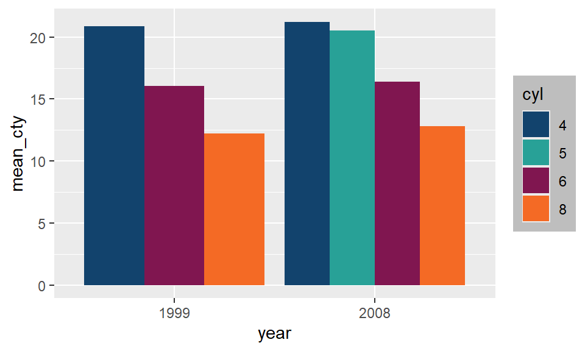

```r
# fill box
p + theme(legend.background = element_rect(fill = "grey"))
```

You can control the palette, breaks, labels, and name. E.g. if the factor labels are too long, you can shorten them. Use a separate call to contol other attributes like `linetype` or `fill`. In fact, the `scale_*_manual` functions are incredibly versatile for this kind of task (and are discussed in more detail below).

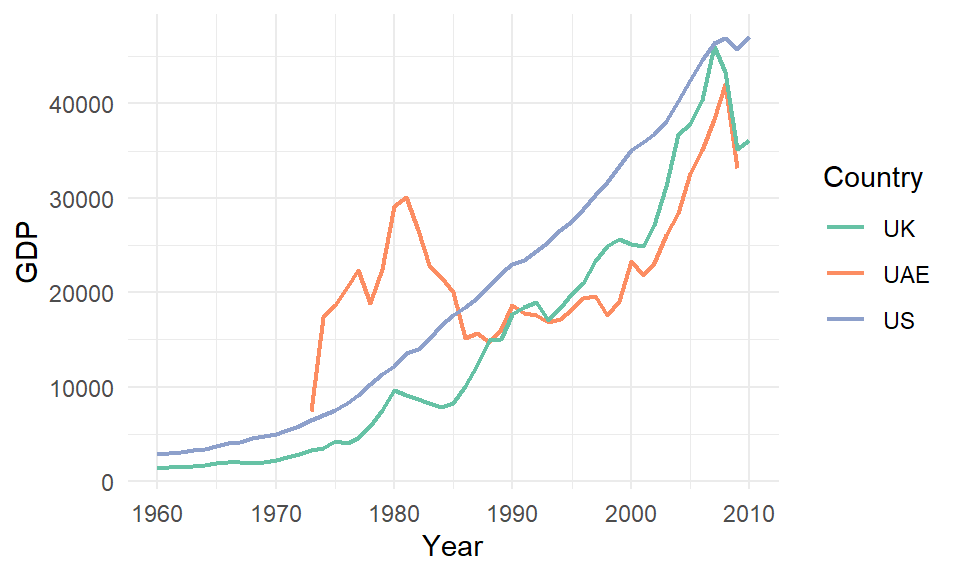

```r
gcookbook::countries %>%
    filter(str_detect(Name, "United")) %>%
    ggplot(aes(x = Year, y = GDP)) +
    geom_line(aes(colour = Name), linewidth = 0.8) +
    scale_colour_manual(values = c(RColorBrewer::brewer.pal(3, "Set2")),
                        breaks = c("United Kingdom", "United Arab Emirates", "United States"),
                        labels = c("UK", "UAE", "US"),
                        name = "Country") +
  theme_minimal()
```

## 8.1 Direct labels

Sometimes a legend isn’t necessary or the right aesthetic choice. Instead, it’s possible to append labels directly to dots or lines using `directlabels` or `ggrepel`.

Using `directlabels` and `geom_dl`. Note that other method options include `first.points` and `last.qp` which adjusts the size of the text automatically). This also requires clipping to be turned off and for the plot margins to be extended (otherwise text won’t be displayed properly).

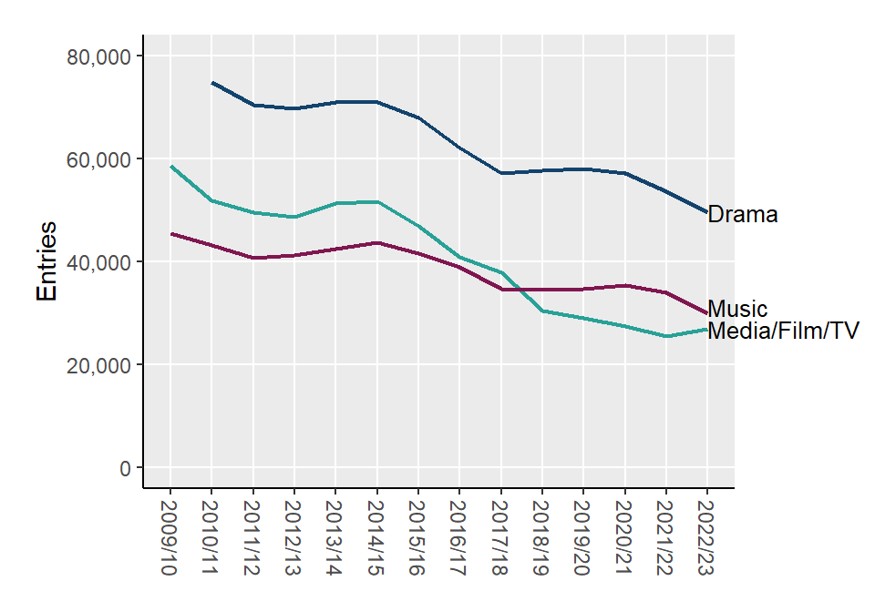

```r
df %>%
  ggplot(aes(x = time_period, y = total_exam_entries)) +
  geom_line(aes(colour = subject), linewidth = 0.8) +
  ylab("Entries") +
  theme(axis.title.x = element_blank(),
        axis.text.x = element_text(angle=270, vjust = 0.5),
        legend.position = "none",
        axis.line = element_line(colour="black"),
        panel.grid.minor = element_blank()) +
  scale_y_continuous(labels = scales::label_comma(big.mark = ","),
                     limits = c(0,80000)) +
  scale_x_continuous(breaks = c(200910, 201011, 201112, 201213, 201314, 201415, 201516, 201617,
                                201718, 201819, 201920, 202021, 202122, 202223),
                     labels = c("2009/10", "2010/11", "2011/12", "2012/13", "2013/14", "2014/15",
                                "2015/16", "2016/17", "2017/18", "2018/19", "2019/20", "2020/21",
                                "2021/22", "2022/23")) +
  geom_dl(aes(label=subject), method=list("last.points", "bumpup", cex=0.8)) +
  coord_cartesian(clip="off") +
  theme(plot.margin = unit(c(1,4,1,1), "lines"))
```

Using `geom_label_repel`. Note that this requires a bit more wrangling to make sure only the final points are displayed (using the `data` argument) - otherwise every single point will be labelled.

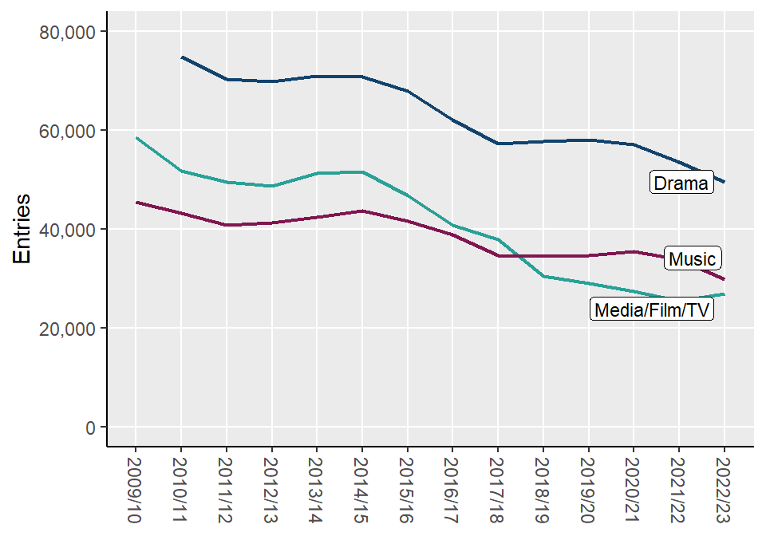

```r
df %>%
  ggplot(aes(x = time_period, y = total_exam_entries, label = subject)) +
  geom_line(aes(colour = subject), linewidth = 0.8) +
  ylab("Entries") +
  theme(axis.title.x = element_blank(),
        axis.text.x = element_text(angle=270, vjust = 0.5),
        legend.position = "none",
        axis.line = element_line(colour="black"),
        panel.grid.minor = element_blank()) +
  scale_y_continuous(labels = scales::label_comma(big.mark = ","),
                     limits = c(0,80000)) +
  scale_x_continuous(breaks = c(200910, 201011, 201112, 201213, 201314, 201415, 201516, 201617,
                                201718, 201819, 201920, 202021, 202122, 202223),
                     labels = c("2009/10", "2010/11", "2011/12", "2012/13", "2013/14", "2014/15",
                                "2015/16", "2016/17", "2017/18", "2018/19", "2019/20", "2020/21",
                                "2021/22", "2022/23")) +
  coord_cartesian(clip = "off") +
  geom_label_repel(aes(label = subject),
                   data = df %>% group_by(subject) %>% filter(time_period == max(time_period)),
                   size = 3,
                   box.padding = 0.25, #increase for more space b/w labels
                   label.padding = 0.15,
                   hjust = 0.5,
                   nudge_x=0.5,
                   force = 1,
                   force_pull = 0)
```

# 9 Other things

## 9.1 Flip coordinates

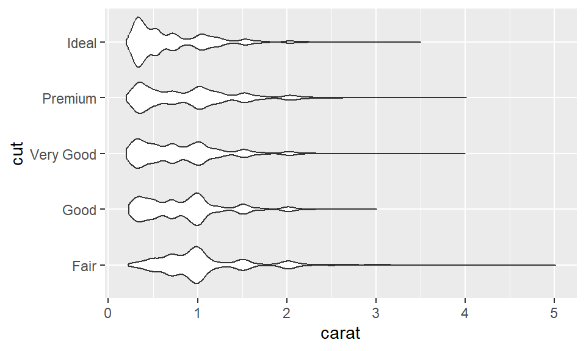

```r
ggplot2::diamonds %>%
  ggplot(aes(x=cut, y=carat)) +
  geom_violin() +
  coord_flip()
```

## 9.2 Multiple sources of data

If you’d like to graph multiple sources of data on the same chart, you need to save this into a separate dataframe. Example: create a time series showing performance on PISA, with red horizontal lines for each year to indicate the study average. This recipe also uses only unique year values for the x-axis (as opposed to regular increments along a scale).

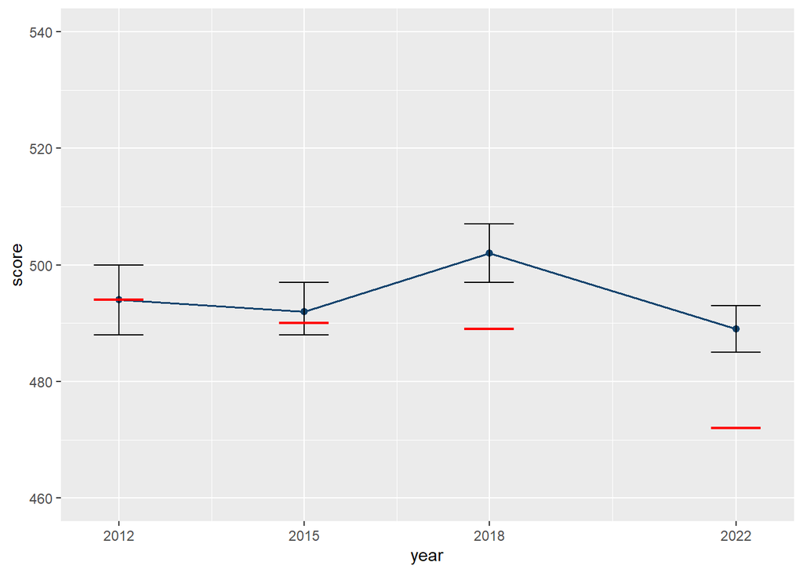

```r
# data
df = data.frame(
  year = c(2012, 2015, 2018, 2022),
  lower = c(488, 488, 497, 485),
  upper = c(500, 497, 507, 493),
  score = c(494, 492, 502, 489),
  oecd_avg = c(494, 490, 489, 472)
)

# 1 - extract unique years for x-axis
yrs = df %>%
  pull(year) %>%
  unique() %>%
  sort()

# 2 - extract the oecd_avg scores
avg = df %>%
  select(year, oecd_avg)

# graph
df %>%
   ggplot(aes(x = year, y = score)) +
  geom_point() +
  geom_line() +
  geom_errorbar(aes(ymin = lower, ymax = upper), width = 0.8) +
  # add average scores
  geom_segment(
    data = avg,
    aes(x = year - 0.4, xend = year + 0.4,
      y = oecd_avg, yend = oecd_avg),
    colour = "red", linewidth = 0.8) +
  # add scales
  scale_y_continuous(limits = c(460, 540)) +
  scale_x_continuous(breaks = yrs)
```

# 10 Using colours

## 10.1 Manual

Quick manual palettes for sequential and categorical variables (adjust to number needed).

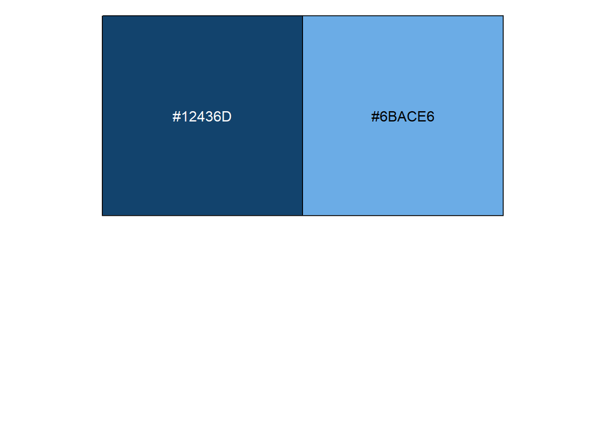

```r
seq2 = c("#12436D", "#6BACE6")
scales::show_col(seq2)
```

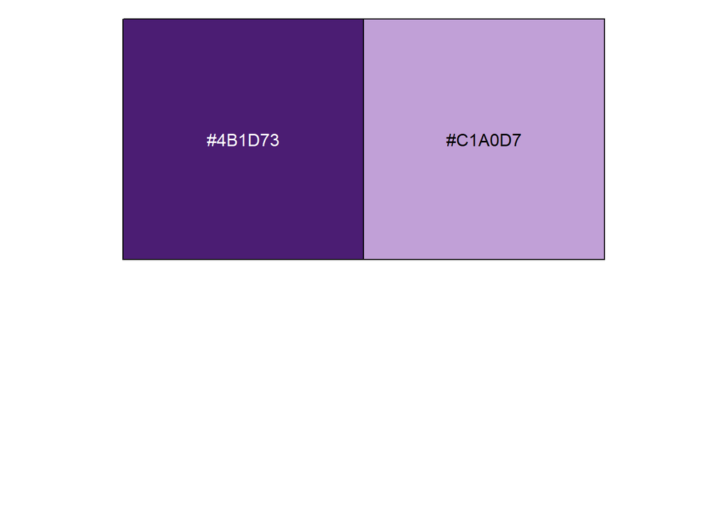

```r
seq2 = c("#4B1D73", "#C1A0D7")
scales::show_col(seq2)
```

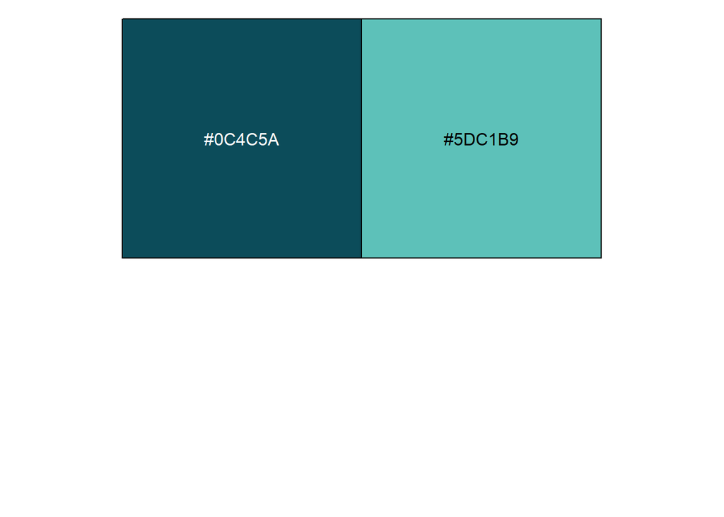

```r
seq2 = c("#0C4C5A", "#5DC1B9")
scales::show_col(seq2)
```

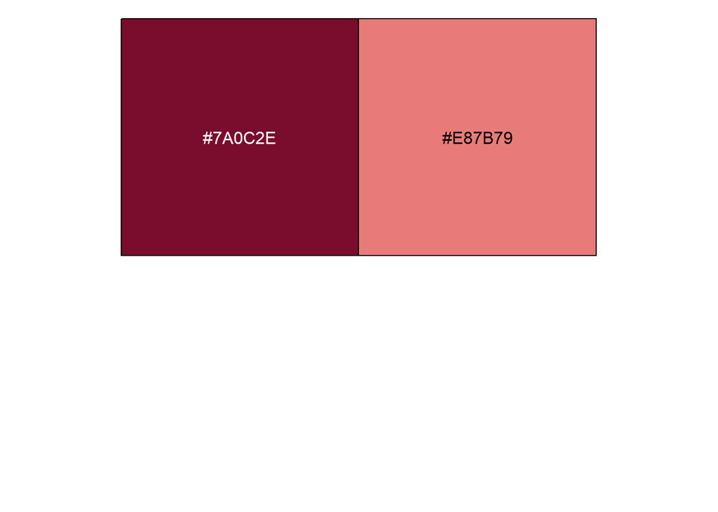

```r
seq2 <- c("#7A0C2E", "#E87B79")
scales::show_col(seq2)
```

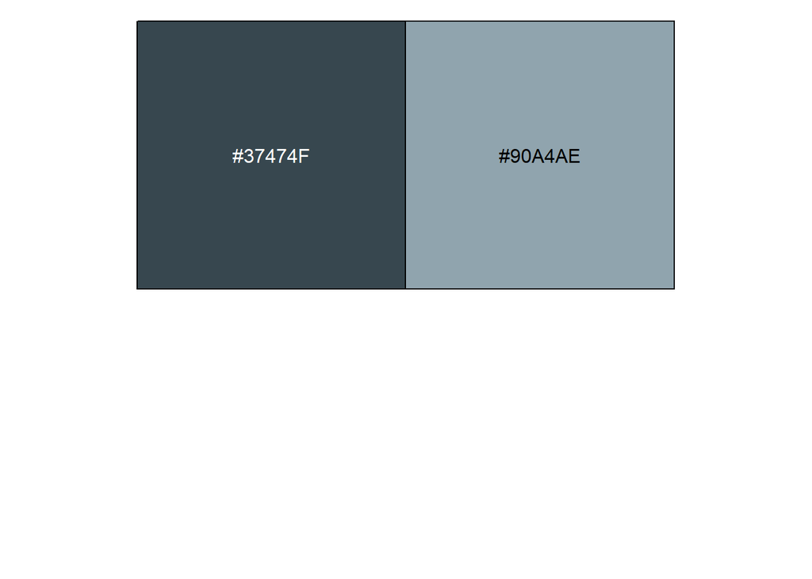

```r
seq2 <- c("#37474F", "#90A4AE")
scales::show_col(seq2)
```

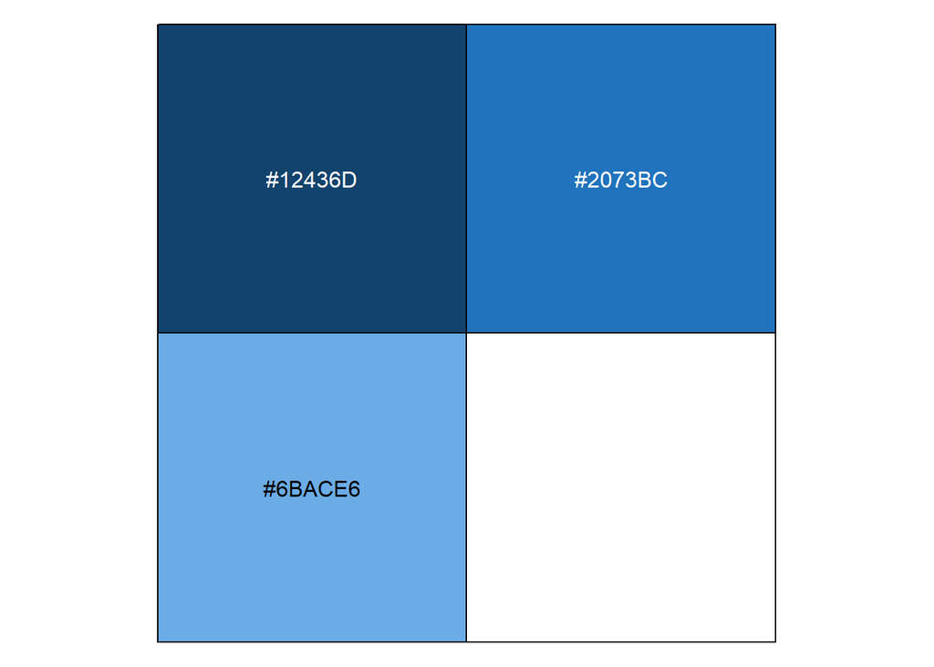

```r
seq3 = c("#12436D", "#2073BC", "#6BACE6")
scales::show_col(seq3)
```

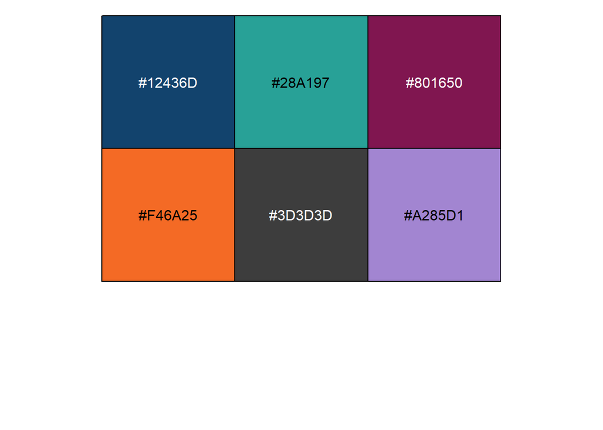

```r
cat4 = c("#12436D", "#28A197", "#801650", "#F46A25", "#3D3D3D", "#A285D1")
scales::show_col(cat4)
```

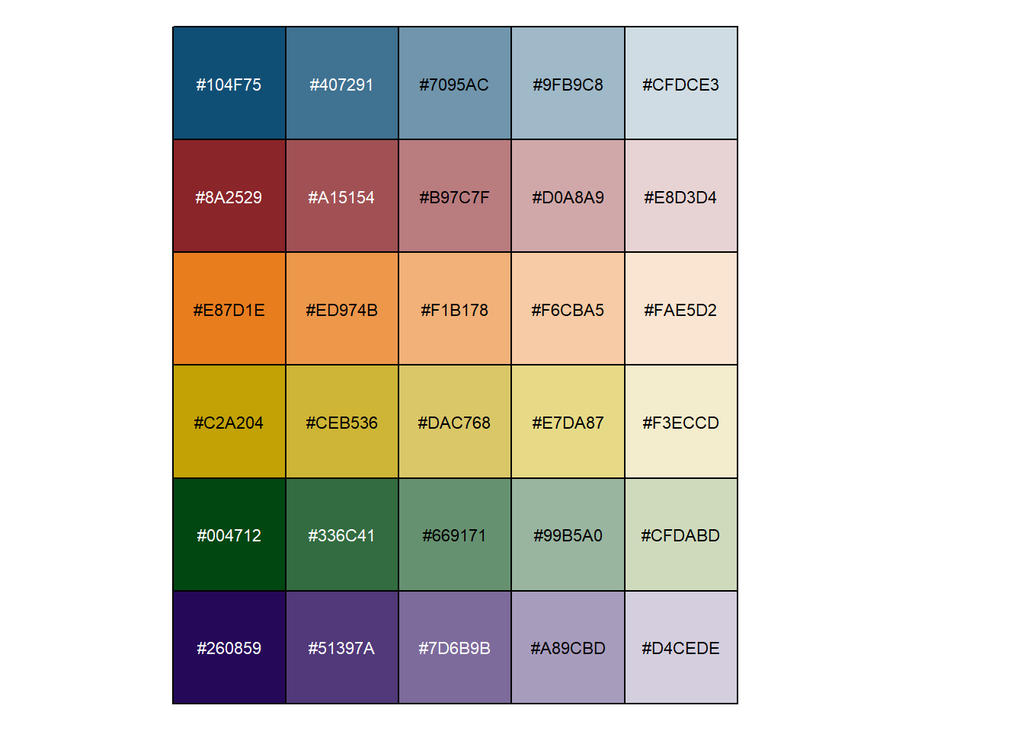

```r
# Sequential palettes
blues = c("#104F75", "#407291", "#7095AC", "#9FB9C8", "#CFDCE3")
reds = c("#8A2529", "#A15154", "#B97C7F", "#D0A8A9", "#E8D3D4")
oranges = c("#E87D1E", "#ED974B", "#F1B178", "#F6CBA5", "#FAE5D2")
yellows = c("#C2A204", "#CEB536", "#DAC768", "#E7DA87", "#F3ECCD")
greens = c("#004712", "#336C41", "#669171", "#99B5A0", "#CFDABD")
purples = c("#260859", "#51397A", "#7D6B9B", "#A89CBD", "#D4CEDE")

show_col(c(blues, reds, oranges, yellows, greens, purples), ncol=5, cex_label=0.7)
```

## 10.2 `scale_*_manual`

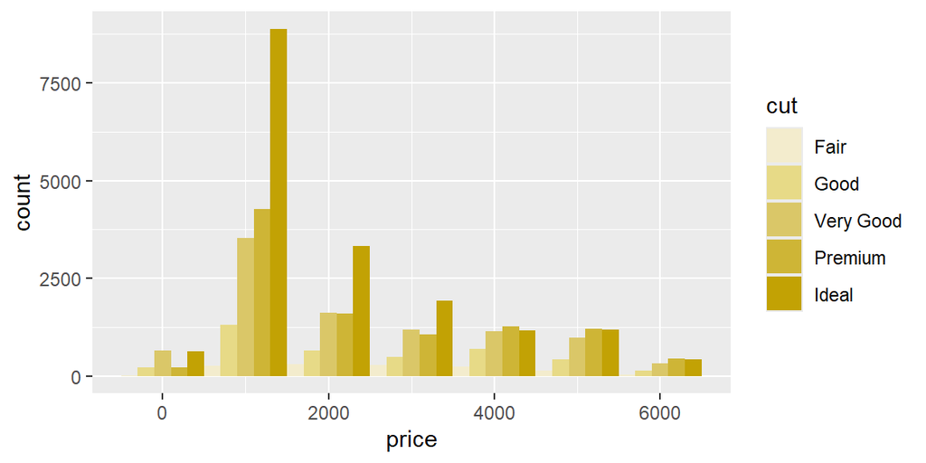

```r
# example of sequential. Tip: use rev() to reverse the order of colours
ggplot2::diamonds %>%
  filter(price < 6000) %>%
  ggplot(aes(x = price, fill = cut)) +
  geom_histogram(position = "dodge", binwidth = 1000) +
  scale_fill_manual(values = rev(yellows))
```

An example of how to specify manual linetype and colour. Note that these must use the same breaks in order to be presented as a single legend (as opposed to separate legends for linetype and for colour):

```r
scale_linetype_manual(name = "",
                        values = c("solid", "dashed"),
                        breaks = c("pay", "median_after_tax"),
                        labels = c("Pay", "Median UK")) +
scale_colour_manual(name = "",
                        values = c("black", "red"),
                        breaks = c("pay", "median_after_tax"),
                        labels = c("Pay", "Median UK"))
```

If you would like NA to be a different colour by default

```r
plot +
  scale_fill_discrete(na.value = "white")
```

Use a focus palette to bring attention to one particular series, while keeping the other data there for comparison.

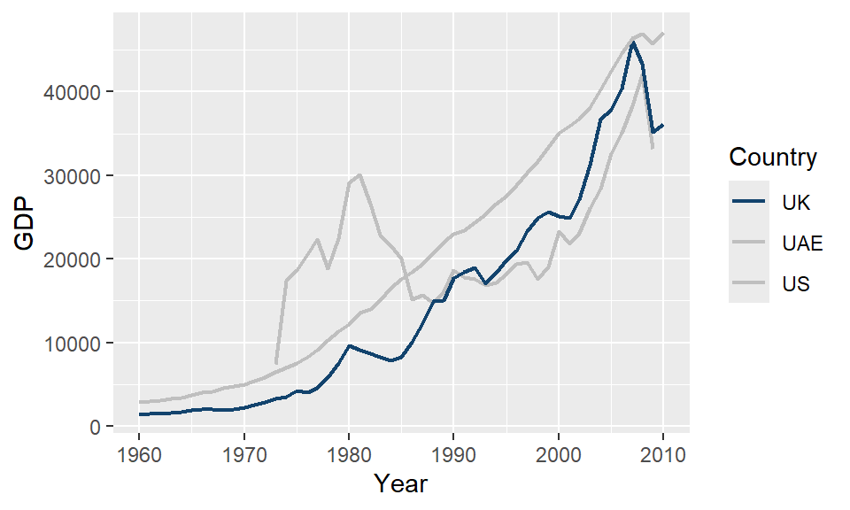

```r
focus = c("#12436D", "#BFBFBF", "#BFBFBF") # contrast ratio of 5.57:1 (passes Web Content Accessibility
# Guidelines [WCAG]).
# Add as many grey colours as you need.

countries %>%
  filter(str_detect(Name, "United")) %>%
  ggplot(aes(x=Year, y=GDP)) +
  geom_line(aes(colour = Name), size = 0.8) +
  scale_colour_manual(values = focus,
                        breaks = c("United Kingdom", "United Arab Emirates", "United States"),
                        labels = c("UK", "UAE", "US"),
                        name = "Country")
```

Alternatively, use `gghighlight`:

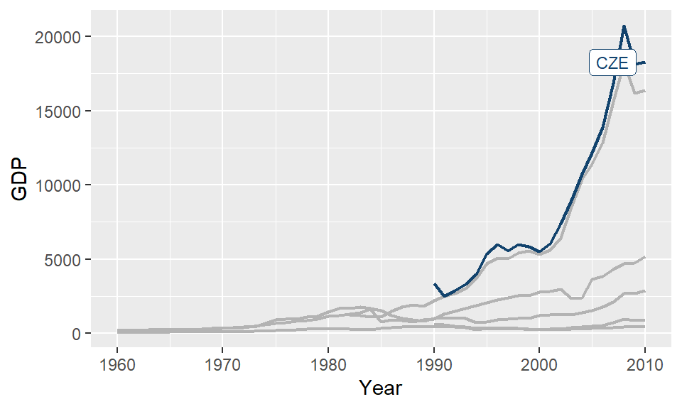

```r
countries %>%
  filter(str_detect(Name, "Republic")) %>%
  ggplot(aes(x=Year, y=GDP)) +
  geom_line(aes(colour = Name), linewidth = 0.8) +
  gghighlight(str_detect(Name, "Czech"),
              label_params = list(size = 3),
              label_key = Code,
              unhighlighted_colour = "grey70")
```

## 10.3 Other colour scale options

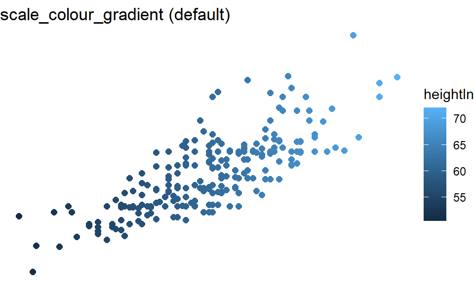

```r
# if a fill or colour variable is continuous, the default scale will be scale_*_continuous,
# so there's no need to specify it directly:
p = gcookbook::heightweight %>%
  ggplot(aes(x = heightIn, y = weightLb, colour = heightIn)) +
  geom_point(size = 2)

# note: scale_colour_continuous works within R but causes a fatal error when
# knitting to html, so replace with scale_colour_gradient

p + scale_colour_gradient(na.value = "grey50") +
  theme_void() +
  ggtitle("scale_colour_gradient (default)")
```

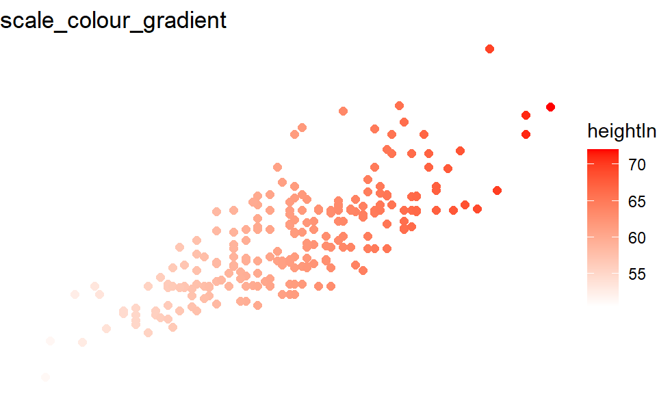

```r
p + scale_colour_gradient(low = "white", high = "red", na.value = "black") +
  theme_void() +
  ggtitle("scale_colour_gradient")
```

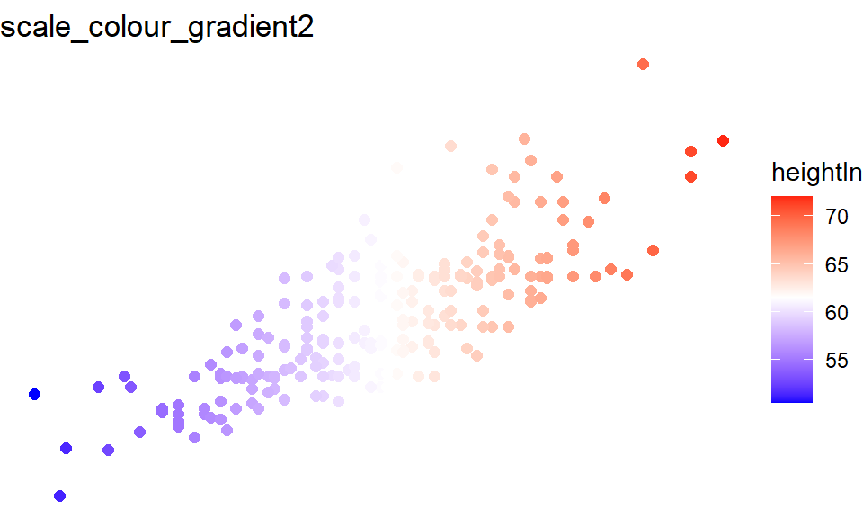

```r
# scale_colour_gradient2 allows you to set a mid-point colour but you have to specify this from
# the dataframe. Of course you don't have to use the median as the 'midpoint' here.
p + scale_colour_gradient2(low = "blue", mid = "white", high = "red",
  midpoint = median(gcookbook::heightweight$heightIn)) +
  theme_void() +
  ggtitle("scale_colour_gradient2")
```

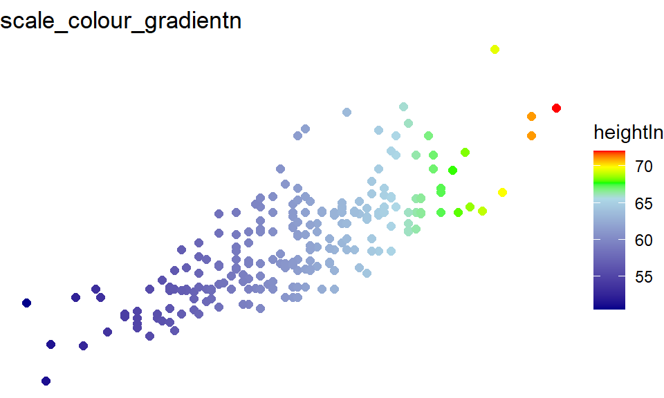

```r
# colour_gradientn allows you to specify your own set of colours for a whole spectrum.
# note: if you don't specify a vector of values, the colours will be evenly positioned along
# the scale. However, you can control this manually for instance if you want to highlight the very
# top values. Just specify a vector of values between 0 and 1 to correspond to how you want the
# colours mapped to the scale, e.g. values = c(1, 0.9, 0.8, 0.7, 0)
p + scale_colour_gradientn(colours = c("red","yellow","green","lightblue","darkblue"),
                                    values = c(1, 0.9, 0.8, 0.7, 0)) +
  theme_void() +
  ggtitle("scale_colour_gradientn")
```

NOTE! If you want to map to integers like 18, 21, 22, 23, 39 then you need to rescale these from 0 to 1, which the `scales` package can do for you:

```r
p + scale_colour_gradientn(colours = c("red","yellow","green","lightblue","darkblue"),
                                    values = scales::rescale(c(39, 23, 22, 21, 18), to = c(0,1)),
                                    name = "Legend name") +
  theme_void()
```

## 10.4 Brewer palettes

`scale_*_brewer` to use predefined palettes. See a list of available palettes [here](https://jmsallan.netlify.app/blog/the-brewer-palettes/).

### 10.4.1 Brewer monochrome palettes:

- Blues
- Greens
- Purples
- Greys
- Oranges
- Reds

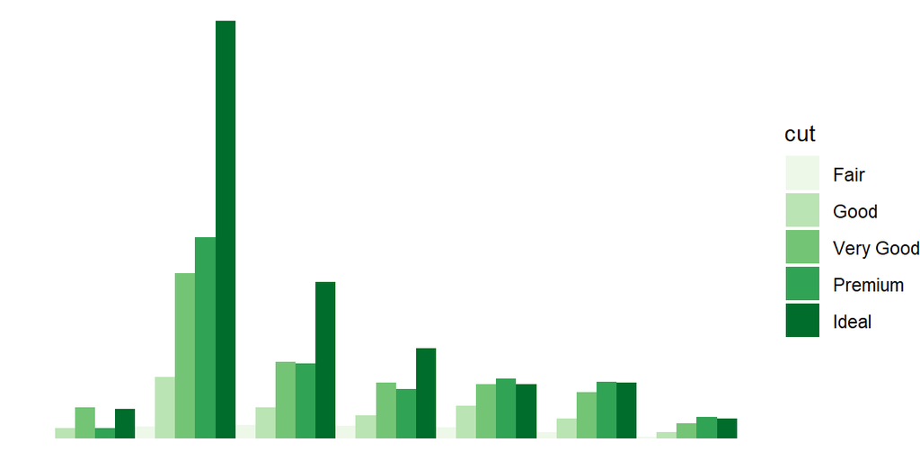

```r
ggplot2::diamonds %>%
  filter(price <6000) %>%
  ggplot(aes(x = price, fill = cut)) +
  geom_histogram(position = "dodge", binwidth = 1000) +
  scale_fill_brewer(palette = "Greens") +
  theme_void()
```

### 10.4.2 Brewer spectral palettes

- BuGn
- BuPu
- GnBu
- OrRed
- PuBu
- PuRd
- RdPu
- YlGn
- PuBuGn
- YlGnBu
- YlOrBr
- YlOrRd

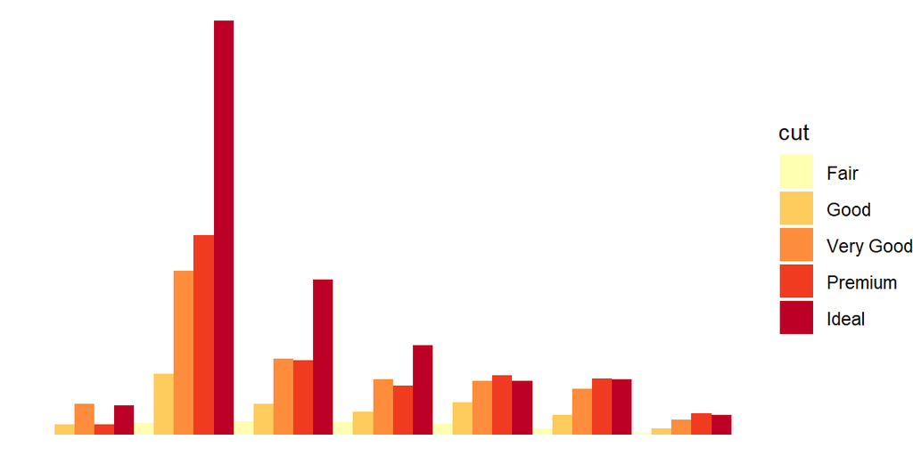

```r
ggplot2::diamonds %>%
  filter(price <6000) %>%
  ggplot(aes(x = price, fill = cut)) +
  geom_histogram(position = "dodge", binwidth = 1000) +
  scale_fill_brewer(palette = "YlOrRd") +
  theme_void()
```

### 10.4.3 Brewer diverging palettes

- Spectral
- RdYlGn
- RdYlBu
- RdGy
- RdBu
- PuOr
- PRGn
- PiYG
- BrBG

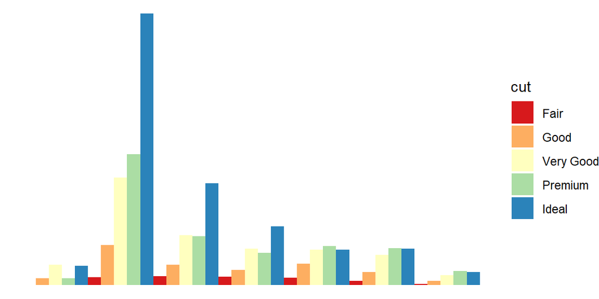

```r
ggplot2::diamonds %>%
  filter(price <6000) %>%
  ggplot(aes(x = price, fill = cut)) +
  geom_histogram(position = "dodge", binwidth = 1000) +
  scale_fill_brewer(palette = "Spectral") +
  theme_void()
```

### 10.4.4 Brewer qualitative palettes

- Accent
- Dark2
- Paired
- Pastel1 and Pastel2
- Set1
- Set2
- Set3

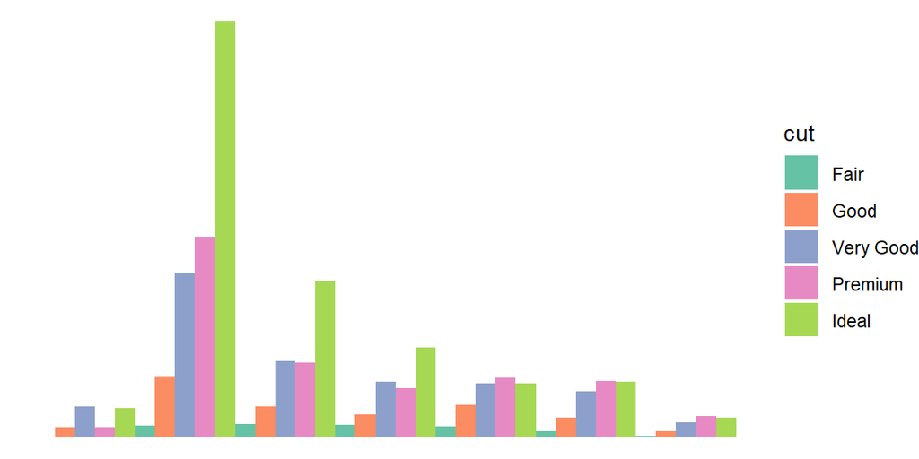

```r
ggplot2::diamonds %>%
  filter(price <6000) %>%
  ggplot(aes(x = price, fill = cut)) +
  geom_histogram(position = "dodge", binwidth = 1000) +
  scale_fill_brewer(palette = "Set2") +
  theme_void()
```

Example of a categorical palette from the [Analysis Function](https://analysisfunction.civilservice.gov.uk/support/communicating-analysis/introduction-to-data-visualisation-e-learning/data-visualisation-e-learning-module-3-accessibility-and-colour-palettes/).

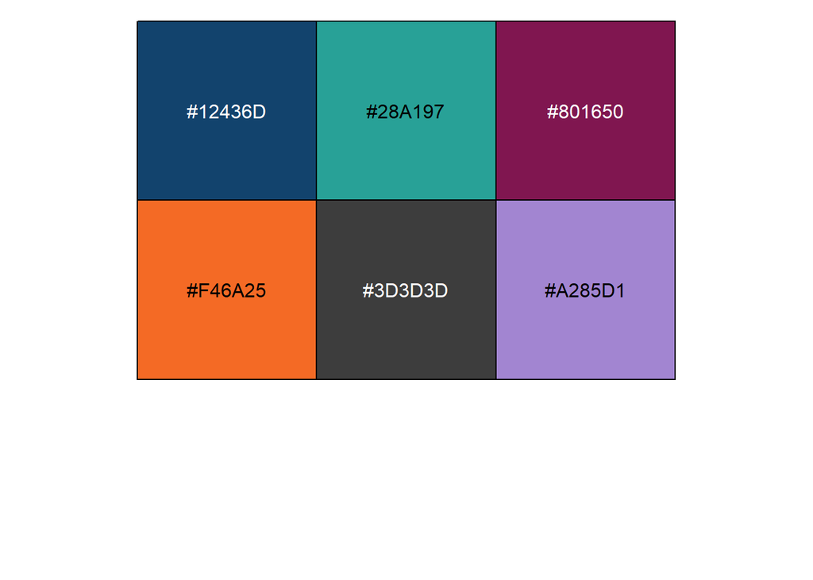

```r
# note: recommendation is to use a max of 4 colours
categorical = c("#12436D", "#28A197", "#801650", "#F46A25", "#3D3D3D", "#A285D1")
show_col(categorical)
```

How to use a custom palette:

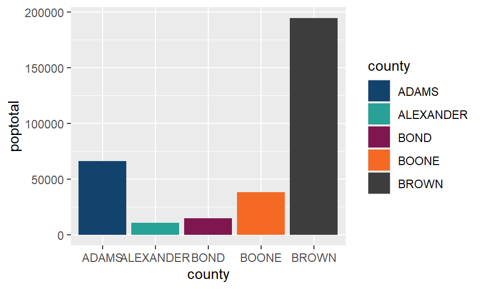

```r
ggplot2::midwest %>%
  filter(county %in% c("ADAMS", "ALEXANDER", "BOND", "BOONE", "BROWN")) %>%
  ggplot(aes(x = county, y = poptotal, fill = county)) +
  geom_col(position = position_dodge()) +
  scale_fill_manual(values = categorical)
```

Using `scale_fill_brewer` palettes:

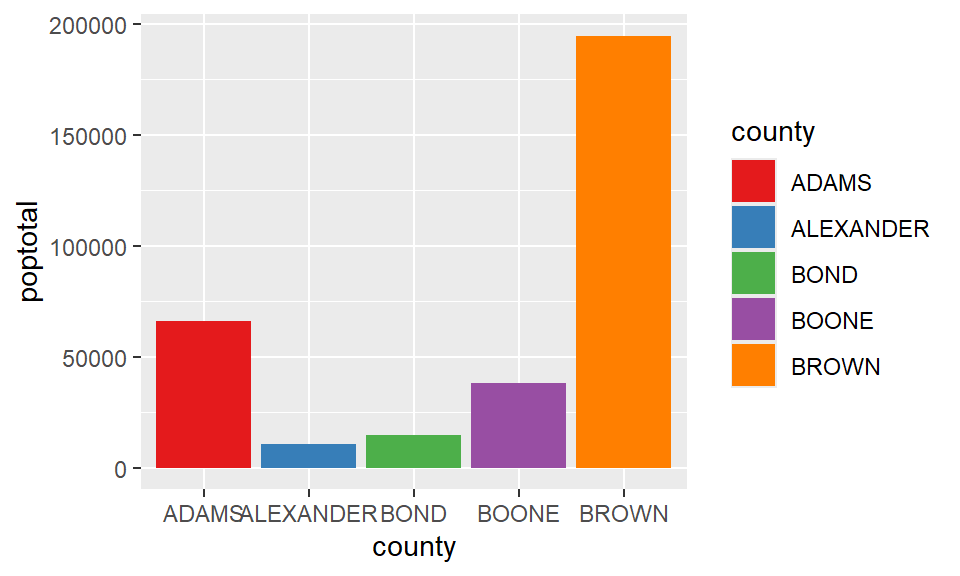

```r
ggplot2::midwest %>%
  filter(county %in% c("ADAMS", "ALEXANDER", "BOND", "BOONE", "BROWN")) %>%
  ggplot(aes(x=county, y=poptotal, fill = county)) +
  geom_col(position = position_dodge()) +
  scale_fill_brewer(type = "seq", palette = "Set1")
```

# 11 Mapping

Use the `sf` package and a shapefile to visualise data on a map. This shapefile comes from the UK government’s [Geoportal](https://geoportal.statistics.gov.uk/search?q=BDY_RGN%3BDEC_2023&sort=Title%7Ctitle%7Casc).

This [tool](https://borders.ukdataservice.ac.uk/bds.html) is also a good resource for finding different shapefiles.

Also see [this 2025 LA shapefile and interactive map](https://geoportal.statistics.gov.uk/datasets/ons::local-authority-districts-may-2025-boundaries-uk-bfe-v2/about).

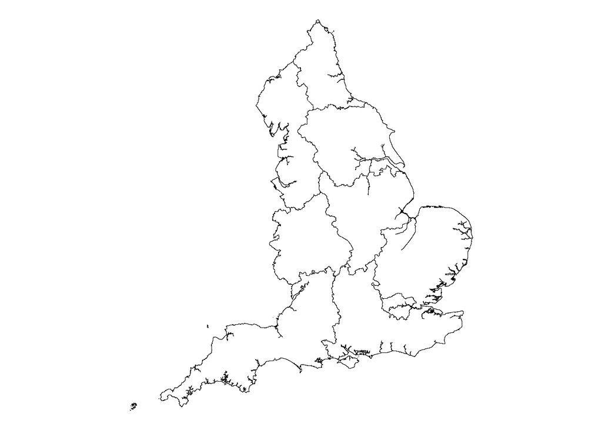

```r
# firstly read in a shapefile. Note that when you download a shapefile, it comes with other
# files like .shx. These all need to be in the same directory as the .shp file itself.
# As such, you can actually just specify the folder name that contains the shapefile and its
# accompanying files.

eng_reg_map = st_read("./Shapefiles/Eng_regional_2023/RGN_DEC_2023_EN_BFC.shp")
# check that the map is appropriate for your needs by graphing it without any data attached
eng_reg_map %>%
  ggplot() +
  geom_sf(fill   = "white",
          colour = "black") +
  theme_void()
```

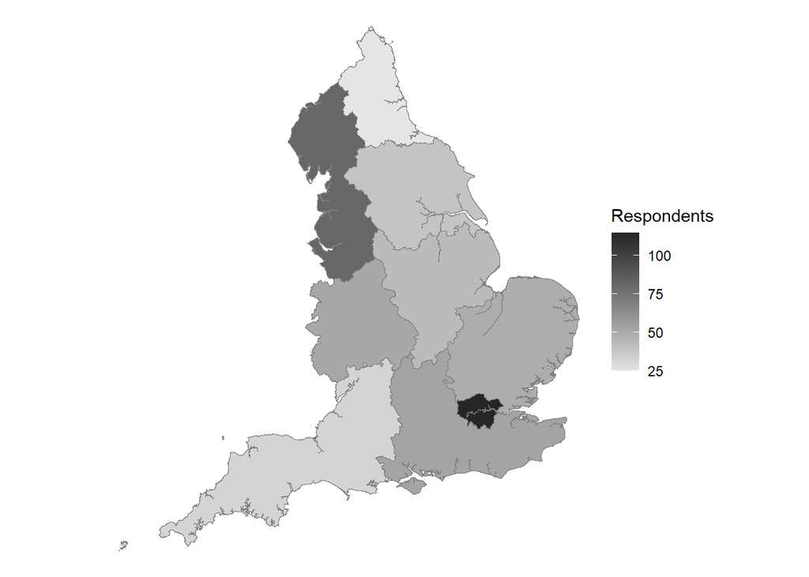

```r
# next, add some data from a preexisting source:
df = data.frame(
  region = c("North West", "North East", "Yorkshire and The Humber",
             "East of England", "West Midlands", "East Midlands",
             "South East", "London", "South West"),
  n = c(81, 25, 39, 49, 51, 43, 53, 115, 32)
)

# join this to the sf object and map.
# use scale_fill_gradient to control fill colours

eng_reg_map %>%
  left_join(df, by = c("RGN23NM" = "region")) %>%
  ggplot(aes(fill = n)) +
  geom_sf(colour = "grey50") +
  theme_void() +
  scale_fill_gradient(name = "Respondents",
                      low = "grey90", high = "grey15",
                      na.value = "white")
```

## 11.1 Adding points based on geometry

```r
# say you have a data frame from GIAS with easting and northing values of schools (these could be lat/long too)
map_df = data.frame(
                    school = c(1:15),
                    easting = c(427144, 390498, 391459, 453596, 332195, 439952, 397143, 331548, 504305, 527647, 349039, 437349, 504740, 448965, 166988),
                    northing = c(433927, 323814, 162039,  86591, 391270, 114064, 157408, 390872, 208312, 169328, 405788, 377158, 103181, 361343,  44078),
                    pupils  = c(28, 23, 59, 22, 28, 76, 13, 14, 57, 43, 25, 12, 59, 52, 31)
)

# the shapefile is based on long/lat, so you need to convert Eastings and Northings.
# The first step here is to check which CRS the original map uses
st_crs(eng_reg_map)$epsg
```

```
[1] 27700
```

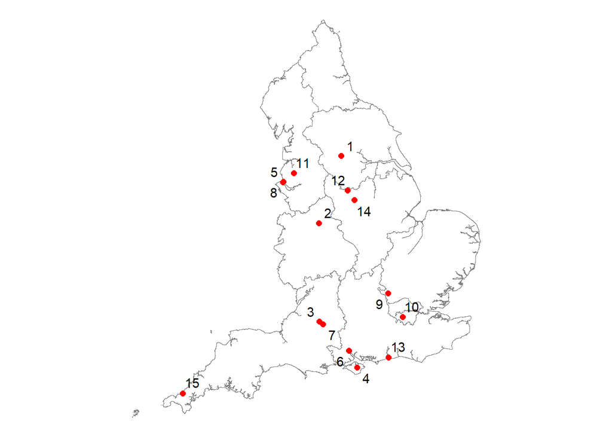

```r
# use the st_as_sf function to create another version of your dataframe (map_df) - feed in the crs
# and it will add an additional column called 'geometry'

schools.sf = st_as_sf(map_df, coords = c("easting", "northing"), remove = FALSE, crs = 27700)

# check that the points themselves work
# plot(schools.sf$geometry)

# add to the map and add text labels
eng_reg_map %>%
  ggplot() +
  geom_sf(fill   = NA,
          colour = "grey50") +
  geom_sf(data = schools.sf, colour = "red", size = 2) +
  ggrepel::geom_text_repel(data = schools.sf,
                  aes(x = st_coordinates(schools.sf)[,1],
                      y = st_coordinates(schools.sf)[,2],
                      label = school)) +
  theme_void()
```

```r
# optionally if you have used aes(colour = pupils): + scale_colour_gradient(low = "grey", high = "red")
```

## 11.2 Local Authority map

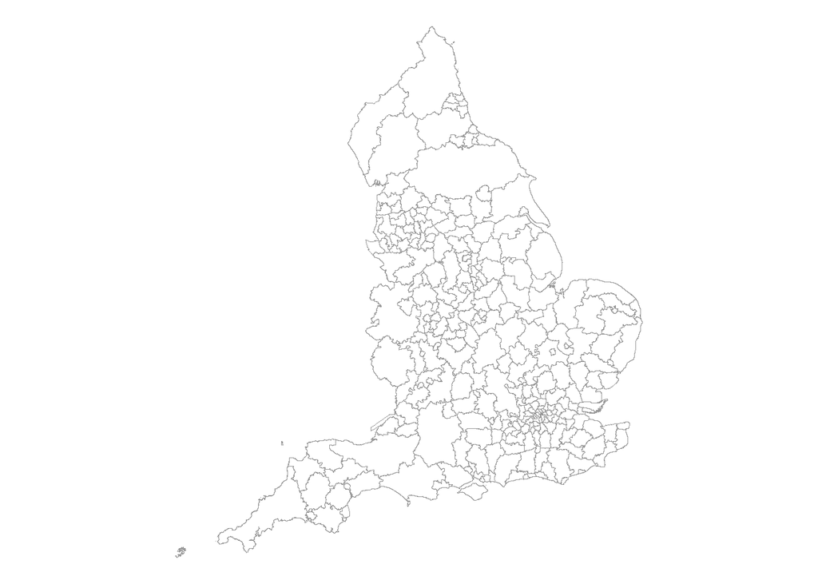

```r
uk_la_map = st_read("./Shapefiles/LAD_MAY_2025_UK_BFE_V2_-726696083958028870/LAD_MAY_2025_UK_BFE_V2.shp")
# limit to England and check map
uk_la_map %>%
  filter(str_detect(LAD25CD, "^E")) %>%
  ggplot() +
  geom_sf(fill = "white", colour = "grey60") +
  theme_void()
```

Overlay certain Local Authorities on the regional shapefile

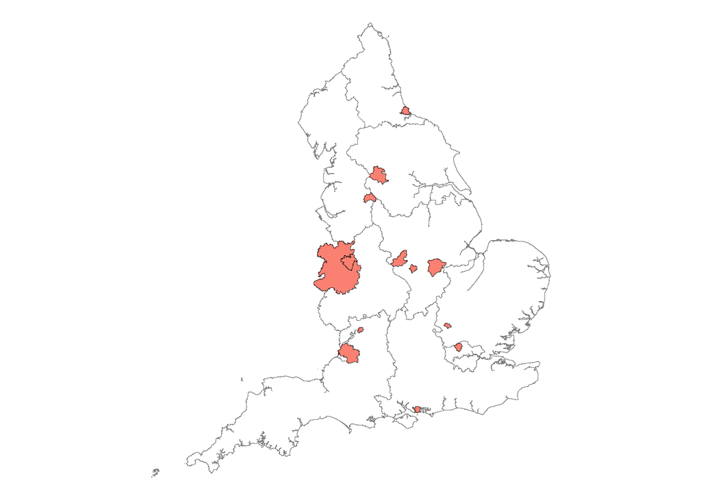

```r
# limit shapefile to desired LAs
la_data = uk_la_map %>%
  filter(LAD25NM %in% c("Barnet", "Bradford", "Gloucester", "South Gloucestershire",
                        "Hartlepool", "Leicester", "North West Leicestershire",
                        "Rutland", "Luton", "Oldham", "Portsmouth", "Telford and Wrekin",
                        "Shropshire"))

eng_reg_map %>%
  ggplot() +
  geom_sf(fill   = NA,
          colour = "grey50") +
  geom_sf(data = la_data, fill="salmon") +
  theme_void()
```

To add labels to geographical areas, you need to compute the centroid (this differs to individual points which have an easting and northing)

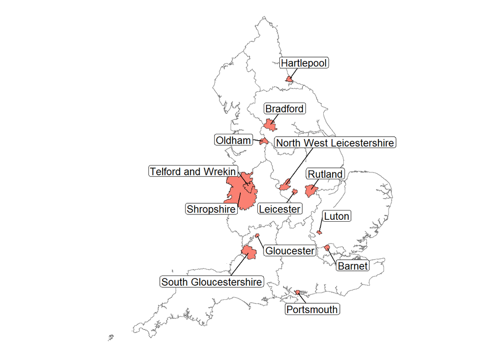

```r
las_labels <- la_data |>
  st_centroid()

coords <- st_coordinates(las_labels)

las_labels <- cbind(las_labels, coords)

eng_reg_map %>%
  ggplot() +
  geom_sf(fill   = NA, colour = "grey50") +
  geom_sf(data = la_data, fill="salmon") +
  ggrepel::geom_label_repel(data = las_labels,
                            aes(X, Y, label = LAD25NM),
                            force_pull = 0.5,
                            force = 1,
                            box.padding = 0.7,
                            nudge_x = 0.2,
                            nudge_y = 0.2,
                            size = 3.5,
                            label.padding = 0.12) +
  theme_void() +
  theme(legend.position = "none")
```